[figure not shown]

# Telecom Churn Case Study

- **Authors:** Anish Mahapatra, Karthik Premanand
- **Email-id:** anishmahapatra01@gmail.com, karthikprem26@gmail.com

*Machine Learning II > Group Case Study 1*

# Problem Statement

The telecommunications insdustry on average experiences a churn of 15-25%. It costs 5-10 times more to acquire a new customer than to retain an existing one. Customer retention has now become more important than customer acquisition.To reduce customer churn, telecom companies need to predict which customers are at a high risk of churn.

The analysis involves customer-level data of a leading telecom firm, building predictive models to identify customers that are at a high risk of churn and to identify the main indicators of churn

#### Methods of defining churn:

- Postpaid: Disrectly inform the operator
- Prepaid: Churn prediction is usually more critical (and non-trivial) for prepaid customers, and the term ‘churn’ should be defined carefully
- Revenue-Based churn: Customers who have not utilised any revenue-generating facilities such as mobile internet, outgoing calls, SMS etc. over a given period of time.

The main shortcoming of this definition is that there are customers who only receive calls/SMSes from their wage-earning counterparts, i.e. they don’t generate revenue but use the services. For example, many users in rural areas only receive calls from their wage-earning siblings in urban areas.

- Usage-based churn: Customers who have not done any usage, either incoming or outgoing - in terms of calls, internet etc. over a period of time.

A potential shortcoming of this definition is that when the customer has stopped using the services for a while, it may be too late to take any corrective actions to retain them. For e.g., if you define churn based on a ‘two-months zero usage’ period, predicting churn could be useless since by that time the customer would have already switched to another operator.

In this project, we will use the **usage-based** definition to define churn.

#### High-value Churn

In the Indian and the southeast Asian market, approximately 80% of revenue comes from the top 20% customers (called high-value customers). Thus, if we can reduce churn of the high-value customers, we will be able to reduce significant revenue leakage.

In this project, you will define high-value customers and predict churn only on high-value customers.

#### Understanding Customer Behaviour During Churn

Customers usually do not decide to switch to another competitor instantly, but rather over a period of time (this is especially applicable to high-value customers). In churn prediction, we assume that there are three phases of customer lifecycle :

- The ‘good’ phase: In this phase, the customer is happy with the service and behaves as usual.
- The ‘action’ phase: The customer experience starts to sore in this phase, for e.g. he/she gets a compelling offer from a competitor, faces unjust charges, becomes unhappy with service quality etc. In this phase, the customer usually shows different behaviour than the ‘good’ months. Also, it is crucial to identify high-churn-risk customers in this phase, since some corrective actions can be taken at this point (such as matching the competitor’s offer/improving the service quality etc.)
- The ‘churn’ phase: In this phase, the customer is said to have churned. You define churn based on this phase. Also, it is important to note that at the time of prediction (i.e. the action months), this data is not available to you for prediction. Thus, after tagging churn as 1/0 based on this phase, you discard all data corresponding to this phase.

#### Data Preparation:

1. Derive new features using business logic
2. Filter high-value customers: Those who have recharged with an amount more than or equal to X, where X is the 70th percentile of the average recharge amount in the first two months (the good phase). After filtering the high-value customers, you should get about 29.9k rows.
3. Tag churners and remove attributes of the churn phase: Now tag the churned customers (churn=1, else 0) based on the fourth month as follows: Those who have not made any calls (either incoming or outgoing) AND have not used mobile internet even once in the churn phase. The attributes you need to use to tag churners are:
- total_ic_mou_9
- total_og_mou_9
- vol_2g_mb_9
- vol_3g_mb_9

After tagging churners, remove all the attributes corresponding to the churn phase (all attributes having ‘ _9’, etc. in their names).

#### Modelling:

Build models to predict churn. The predictive model that you’re going to build will serve two purposes:

1. It will be used to predict whether a high-value customer will churn or not, in near future (i.e. churn phase). By knowing this, the company can take action steps such as providing special plans, discounts on recharge etc. (PCA + + Class-Imbalance + Classification)
2. It will be used to identify important variables that are strong predictors of churn. These variables may also indicate why customers choose to switch to other networks.

You can take the following suggestive steps to build the model:

- Preprocess data (convert columns to appropriate formats, handle missing values, etc.)
- Conduct appropriate exploratory analysis to extract useful insights (whether directly useful for business or for eventual modelling/feature engineering).
- Derive new features.
- Reduce the number of variables using PCA.
- Train a variety of models, tune model hyperparameters, etc. (handle class imbalance using appropriate techniques).
- Evaluate the models using appropriate evaluation metrics. Note that is is more important to identify churners than the non-churners accurately - choose an appropriate evaluation metric which reflects this business goal.
- Finally, choose a model based on some evaluation metric.

Build another model with the main objective of identifying important predictor attributes which help the business understand indicators of churn. A good choice to identify important variables is a logistic regression model or a model from the tree family. In case of logistic regression, make sure to handle multi-collinearity.

After identifying important predictors, display them visually - you can use plots, summary tables etc. - whatever you think best conveys the importance of features.

Finally, recommend strategies to manage customer churn based on your observations.

### Goals of case Study:

The business objective is to predict the churn in the last (i.e. the ninth) month using the data (features) from the first three months. To do this task well, understanding the typical customer behaviour during churn will be helpful.

## Evaluation Rubric:

- Data Quality Checks - missing value imputation, removing duplicate data, data redundancies
- Data Quality Issues mentioned and clearly explained in comments
- EDA using plots and summaries
- Filter high-value customers
- Feature engineering is done rigorusly and correctly

#### 1. Data Cleaning

- Handle actual missing values - done
- Find percentage of missing values - done
- Drop columns that have a high percentage of missing values - done
- Drop columns that are highly skewed - done columns with the same value have been dropped
- Impute data wherever required - done, simple ad advanced methods have been used
- Scale the data - done

#### 2. Modeling

- PCA or some sort of dimensionality reduction technique is used, inclusing the data preparations required for it - done
- Class imbalance is used for at least one of the techniques - done, SMOTE has been used
- Model hyperparameters are tuned using correct principles and the approach is explained clearly - done
- A reasonable number and variety of different models are attempted and the best one is chosen based on key performance metrics - done
- Model evaluation is conducted using an appropriate metric - done, Sensitivity and Type 2 error have been used
- Model evaluation results are at par with the best possible models on this data set - done

#### 3. Factors affecting Customer Churn and Business Recommendations

- Important churn indicators are identified correctly - done
- Clear actionable recommendations are provided based on supporting evidence - done

#### Additional Notes:

- Data cleaning using advanced techniques such as iterative imputer, KNN IMputer
- Filter HVC. Use month 6 and month 7 data. Make 2 derived columns:

total_rech_6 = total_calling_6 + total_data_6

total_rech_7 = total_calling_7 + total_data_7

avg_rech_6_7 = (total_rech_6 + total_rech_7) / 2

Find 70th percentile value here and filter out > 70 percentile customers - The numbr of rows will be around 30k

- Derive churn using month 9. Any customer that has calling = 0 and data = 0, then churn = 1

calling_minutes_9 = calling_minutes_incoming_9 + calling_minutes_outgoing_9 is equal to zero AND

data_usage = data_usage_2g_9 + data_usage_3g_9 is zero, Then the customer is churned

Remove all the columns corresponding to month 9

- EDA, Train-test split, Outlier Treatment
- Class Imbalance Techniques - SMOTE, Weight of Class
- Modelling: Interpretable Model: 1 technique -> Random Forest, Logistic Regression + RFE, Model with good prediction: With PCA -> At least 3 different techniques - Logistic Regression, Regularized regression, Decision Trees, Random Forest, SVM Perform hyper-parameter tuning
- Look at sensitivity and make sure that Type 2 error is low

### Purpose of the notebook.

The purpose of the notebook as follows:

1. Predict the churn of the customer in the 9th month
2. Identify the factors that affect the churn of the customer

Following are the steps to the followed to perform the analysis:

- #1 Data load, importing libraries & Sense Check of Data
- #2 Data Cleaning, Missing Value Treatment
- #3 Subsetting High-Value Customers using 70 percentile value
- #4 Feature Engineering and derived columns
- #5 Obtaining Customer Churn (1 - Churn, 0 - No Churn)
- #6 Exploratory Data Analysis (EDA)
  - #6.1 Univariate and Bivariate Analysis of Columns
  - #6.2 Outlier Analysis of the Data
- #7 Test-Train Split, Feature Scaling & Handling Class Imbalance in the data - SMOTE
- #8 Modelling - Part 1: Obtaining best churn classification
  - #8.1 PCA
    - #8.1.1 Standardizing the data
    - #8.1.2 PCA on the dataset
    - #8.1.3 Scree Plot
    - #8.1.4 Plotting the Heatmap
    - #8.1.5 PCA Analysis
    - #8.1.6 Test PCA for the rest of the algorithms
  - #8.2 Algorithm 1: Logistic Regression + RFE
    - #8.2.1 Recursive Feature Elimination
    - #8.2.2 Model Iterations, hyperparameter tuning
    - #8.2.3 Variance Inflation Factor (VIF)
    - #8.2.4 Residual Analysis of Train Data
    - #8.2.5 Making Predictions
    - #8.2.6 Analysis of Results - Sensitivity and Type 2 Error
  - #8.3 Algorithm 2: Random Forest
    - #8.3.1 Analysis of Feature to be predicted
    - #8.3.2 Hyperparameter Tuning
    - #8.3.3 Grid Search
    - #8.3.4 Analysis of Results - Sensitivity and Type 2 Error
  - #8.4 Algorithm 3: Support Vector Machine [Best Results!]
    - #8.4.1 Running defaut Support Vector Mchine
    - #8.4.2 Hyperparameter tuning via GridSearch CV
    - #8.4.3 Analysis of Results - Sensitivity and Type 2 Error
- #9 Modelling - Part 2: Interpretable Results
  - #9.1 Logistic Regression + RFE
    - #9.2.1 Recursive Feature Elimination
    - #9.2.2 Model Iterations
    - #9.2.3 Variance Inflation Factor (VIF)
    - #9.2.4 Residual Analysis of Train Data
    - #9.2.5 Making Predictions
    - #9.2.6 Analysis of Results - Sensitivity and Type 2 Error
- #10 Model Output Discussion
- #11 Outputs of the Analysis
- #12 Business Recommendations to reduce churn

## #1 Data load, importing libraries & Sense Check of Data

```python
# Importing the required packages

from sklearn.linear_model import LinearRegression
from sklearn.model_selection import GridSearchCV
from sklearn.linear_model import Ridge
from sklearn.linear_model import Lasso
from sklearn import linear_model
import matplotlib.pyplot as plt
import seaborn as sns
import pandas as pd
import numpy as np
import os

# Hide warnings

import warnings
warnings.filterwarnings('ignore')
```

```python
# Removing the minimum display columns to 500
pd.set_option('display.max_columns', 500)
pd.set_option('display.max_rows', 500)

# Ignoring warnings
warnings.filterwarnings("ignore")
```

```python
# Reading the dataset
telecom = pd.read_csv("Data/telecom_churn_data.csv")
```

```python
# Sense Check of the Data
telecom.head()
```

|  | mobile_number | circle_id | loc_og_t2o_mou | std_og_t2o_mou | loc_ic_t2o_mou | last_date_of_month_6 | last_date_of_month_7 | last_date_of_month_8 | last_date_of_month_9 | arpu_6 | arpu_7 | arpu_8 | arpu_9 | onnet_mou_6 | onnet_mou_7 | onnet_mou_8 | onnet_mou_9 | offnet_mou_6 | offnet_mou_7 | offnet_mou_8 | offnet_mou_9 | roam_ic_mou_6 | roam_ic_mou_7 | roam_ic_mou_8 | roam_ic_mou_9 | roam_og_mou_6 | roam_og_mou_7 | roam_og_mou_8 | roam_og_mou_9 | … |
| --- | --- | --- | --- | --- | --- | --- | --- | --- | --- | --- | --- | --- | --- | --- | --- | --- | --- | --- | --- | --- | --- | --- | --- | --- | --- | --- | --- | --- | --- | --- |
| 0 | 7000842753 | 109 | 0.0 | 0.0 | 0.0 | 6/30/2014 | 7/31/2014 | 8/31/2014 | 9/30/2014 | 197.385 | 214.816 | 213.803 | 21.100 | NaN | NaN | 0.00 | NaN | NaN | NaN | 0.00 | NaN | NaN | NaN | 0.00 | NaN | NaN | NaN | 0.00 | NaN | … |
| 1 | 7001865778 | 109 | 0.0 | 0.0 | 0.0 | 6/30/2014 | 7/31/2014 | 8/31/2014 | 9/30/2014 | 34.047 | 355.074 | 268.321 | 86.285 | 24.11 | 78.68 | 7.68 | 18.34 | 15.74 | 99.84 | 304.76 | 53.76 | 0.0 | 0.00 | 0.00 | 0.00 | 0.0 | 0.00 | 0.00 | 0.00 | … |
| 2 | 7001625959 | 109 | 0.0 | 0.0 | 0.0 | 6/30/2014 | 7/31/2014 | 8/31/2014 | 9/30/2014 | 167.690 | 189.058 | 210.226 | 290.714 | 11.54 | 55.24 | 37.26 | 74.81 | 143.33 | 220.59 | 208.36 | 118.91 | 0.0 | 0.00 | 0.00 | 38.49 | 0.0 | 0.00 | 0.00 | 70.94 | … |
| 3 | 7001204172 | 109 | 0.0 | 0.0 | 0.0 | 6/30/2014 | 7/31/2014 | 8/31/2014 | 9/30/2014 | 221.338 | 251.102 | 508.054 | 389.500 | 99.91 | 54.39 | 310.98 | 241.71 | 123.31 | 109.01 | 71.68 | 113.54 | 0.0 | 54.86 | 44.38 | 0.00 | 0.0 | 28.09 | 39.04 | 0.00 | … |
| 4 | 7000142493 | 109 | 0.0 | 0.0 | 0.0 | 6/30/2014 | 7/31/2014 | 8/31/2014 | 9/30/2014 | 261.636 | 309.876 | 238.174 | 163.426 | 50.31 | 149.44 | 83.89 | 58.78 | 76.96 | 91.88 | 124.26 | 45.81 | 0.0 | 0.00 | 0.00 | 0.00 | 0.0 | 0.00 | 0.00 | 0.00 | … |

```python
# Viewing the shape of the data
telecom.shape
```

```
(99999, 226)
```

```python
# Summary of the dataset
print(telecom.info(verbose=True))
```

```
<class 'pandas.core.frame.DataFrame'>
RangeIndex: 99999 entries, 0 to 99998
Data columns (total 226 columns):
mobile_number               int64
circle_id                   int64
loc_og_t2o_mou              float64
std_og_t2o_mou              float64
loc_ic_t2o_mou              float64
last_date_of_month_6        object
last_date_of_month_7        object
last_date_of_month_8        object
last_date_of_month_9        object
arpu_6                      float64
arpu_7                      float64
arpu_8                      float64
arpu_9                      float64
onnet_mou_6                 float64
onnet_mou_7                 float64
onnet_mou_8                 float64
onnet_mou_9                 float64
offnet_mou_6                float64
offnet_mou_7                float64
offnet_mou_8                float64
offnet_mou_9                float64
roam_ic_mou_6               float64
roam_ic_mou_7               float64
roam_ic_mou_8               float64
roam_ic_mou_9               float64
roam_og_mou_6               float64
roam_og_mou_7               float64
roam_og_mou_8               float64
roam_og_mou_9               float64
loc_og_t2t_mou_6            float64
loc_og_t2t_mou_7            float64
loc_og_t2t_mou_8            float64
loc_og_t2t_mou_9            float64
loc_og_t2m_mou_6            float64
loc_og_t2m_mou_7            float64
loc_og_t2m_mou_8            float64
loc_og_t2m_mou_9            float64
```

[output cut: 177 more lines]

```
sachet_3g_7                 int64
sachet_3g_8                 int64
sachet_3g_9                 int64
fb_user_6                   float64
fb_user_7                   float64
fb_user_8                   float64
fb_user_9                   float64
aon                         int64
aug_vbc_3g                  float64
jul_vbc_3g                  float64
jun_vbc_3g                  float64
sep_vbc_3g                  float64
dtypes: float64(179), int64(35), object(12)
memory usage: 172.4+ MB
None
```

```python
# Printing all the columns with atleast one null value
telecom.columns[telecom.isna().any()].tolist()
```

```
['loc_og_t2o_mou',
 'std_og_t2o_mou',
 'loc_ic_t2o_mou',
 'last_date_of_month_7',
 'last_date_of_month_8',
 'last_date_of_month_9',
 'onnet_mou_6',
 'onnet_mou_7',
 'onnet_mou_8',
 'onnet_mou_9',
 'offnet_mou_6',
 'offnet_mou_7',
 'offnet_mou_8',
 'offnet_mou_9',
 'roam_ic_mou_6',
 'roam_ic_mou_7',
 'roam_ic_mou_8',
 'roam_ic_mou_9',
 'roam_og_mou_6',
 'roam_og_mou_7',
 'roam_og_mou_8',
 'roam_og_mou_9',
 'loc_og_t2t_mou_6',
 'loc_og_t2t_mou_7',
 'loc_og_t2t_mou_8',
 'loc_og_t2t_mou_9',
 'loc_og_t2m_mou_6',
 'loc_og_t2m_mou_7',
 'loc_og_t2m_mou_8',
 'loc_og_t2m_mou_9',
 'loc_og_t2f_mou_6',
 'loc_og_t2f_mou_7',
 'loc_og_t2f_mou_8',
 'loc_og_t2f_mou_9',
 'loc_og_t2c_mou_6',
 'loc_og_t2c_mou_7',
 'loc_og_t2c_mou_8',
 'loc_og_t2c_mou_9',
 'loc_og_mou_6',
 'loc_og_mou_7',
```

[output cut: 111 more lines]

```
 'arpu_3g_7',
 'arpu_3g_8',
 'arpu_3g_9',
 'arpu_2g_6',
 'arpu_2g_7',
 'arpu_2g_8',
 'arpu_2g_9',
 'night_pck_user_6',
 'night_pck_user_7',
 'night_pck_user_8',
 'night_pck_user_9',
 'fb_user_6',
 'fb_user_7',
 'fb_user_8',
 'fb_user_9']
```

There are 99999 rows, 226 columns, in the dataset out of which 166 columns have null values

## #2 Data Cleaning, Missing Value Treatment

```python
df = telecom.copy(deep=True)
```

```python
# Visulalizing the percentage of missing values
missing = (df.isnull().sum() / len(df)) * 100
missing_df = pd.DataFrame({'Feature': df.columns,
                                 'missing (%)': missing})

missing_df
```

|  | Feature | missing (%) |
| --- | --- | --- |
| mobile_number | mobile_number | 0.000000 |
| circle_id | circle_id | 0.000000 |
| loc_og_t2o_mou | loc_og_t2o_mou | 1.018010 |
| std_og_t2o_mou | std_og_t2o_mou | 1.018010 |
| loc_ic_t2o_mou | loc_ic_t2o_mou | 1.018010 |
| last_date_of_month_6 | last_date_of_month_6 | 0.000000 |
| last_date_of_month_7 | last_date_of_month_7 | 0.601006 |
| last_date_of_month_8 | last_date_of_month_8 | 1.100011 |
| last_date_of_month_9 | last_date_of_month_9 | 1.659017 |
| arpu_6 | arpu_6 | 0.000000 |
| arpu_7 | arpu_7 | 0.000000 |
| arpu_8 | arpu_8 | 0.000000 |
| arpu_9 | arpu_9 | 0.000000 |
| onnet_mou_6 | onnet_mou_6 | 3.937039 |
| onnet_mou_7 | onnet_mou_7 | 3.859039 |
| onnet_mou_8 | onnet_mou_8 | 5.378054 |
| onnet_mou_9 | onnet_mou_9 | 7.745077 |
| offnet_mou_6 | offnet_mou_6 | 3.937039 |
| offnet_mou_7 | offnet_mou_7 | 3.859039 |
| offnet_mou_8 | offnet_mou_8 | 5.378054 |
| offnet_mou_9 | offnet_mou_9 | 7.745077 |
| roam_ic_mou_6 | roam_ic_mou_6 | 3.937039 |
| roam_ic_mou_7 | roam_ic_mou_7 | 3.859039 |
| roam_ic_mou_8 | roam_ic_mou_8 | 5.378054 |
| roam_ic_mou_9 | roam_ic_mou_9 | 7.745077 |
| roam_og_mou_6 | roam_og_mou_6 | 3.937039 |
| roam_og_mou_7 | roam_og_mou_7 | 3.859039 |
| roam_og_mou_8 | roam_og_mou_8 | 5.378054 |
| roam_og_mou_9 | roam_og_mou_9 | 7.745077 |
| loc_og_t2t_mou_6 | loc_og_t2t_mou_6 | 3.937039 |

[output cut: 196 more lines]

```python
print(telecom['arpu_3g_6'].describe())
```

```
count    25153.000000
mean        89.555057
std        193.124653
min        -30.820000
25%          0.000000
50%          0.480000
75%        122.070000
max       6362.280000
Name: arpu_3g_6, dtype: float64
```

We realize that a lot of the columns have 'NA' values. There are two kinds of missing values here:

- Actual missing -
  - date_of_last_rech_data_6
  - date_of_last_rech_data_7
  - date_of_last_rech_data_8
  - date_of_last_rech_data_9
  - total_rech_data_6
  - total_rech_data_7
  - total_rech_data_8
  - total_rech_data_9
  - max_rech_data_6
  - max_rech_data_7
  - max_rech_data_8
  - max_rech_data_9
  - av_rech_amt_data_6
  - av_rech_amt_data_7
  - av_rech_amt_data_8
  - av_rech_amt_data_9
- Imputing the values with zero
  - arpu_3g_6
  - arpu_3g_7
  - arpu_3g_8
  - arpu_3g_9
  - arpu_2g_6
  - arpu_2g_7
  - arpu_2g_8
  - arpu_2g_9
- Meaningful NA values -
  - fb_user_6
  - fb_user_7
  - fb_user_8
  - fb_user_9
  - night_pck_user_6
  - night_pck_user_7
  - night_pck_user_8
  - night_pck_user_9
  - count_rech_2g_6
  - count_rech_2g_7
  - count_rech_2g_8
  - count_rech_2g_9
  - count_rech_3g_6
  - count_rech_3g_7
  - count_rech_3g_8
  - count_rech_3g_9

```python
# Handling indicative missing values
df['arpu_3g_6'].fillna(0, inplace = True)
df['arpu_3g_7'].fillna(0, inplace = True)
df['arpu_3g_8'].fillna(0, inplace = True)
df['arpu_3g_9'].fillna(0, inplace = True)
df['arpu_2g_6'].fillna(0, inplace = True)
df['arpu_2g_7'].fillna(0, inplace = True)
df['arpu_2g_8'].fillna(0, inplace = True)
df['arpu_2g_9'].fillna(0, inplace = True)
df['fb_user_6'].fillna(0, inplace = True)
df['fb_user_7'].fillna(0, inplace = True)
df['fb_user_8'].fillna(0, inplace = True)
df['fb_user_9'].fillna(0, inplace = True)
df['night_pck_user_6'].fillna(0, inplace = True)
df['night_pck_user_7'].fillna(0, inplace = True)
df['night_pck_user_8'].fillna(0, inplace = True)
df['night_pck_user_9'].fillna(0, inplace = True)
df['count_rech_2g_6'].fillna(0, inplace = True)
df['count_rech_2g_7'].fillna(0, inplace = True)
df['count_rech_2g_8'].fillna(0, inplace = True)
df['count_rech_2g_9'].fillna(0, inplace = True)
df['count_rech_3g_6'].fillna(0, inplace = True)
df['count_rech_3g_7'].fillna(0, inplace = True)
df['count_rech_3g_8'].fillna(0, inplace = True)
df['count_rech_3g_9'].fillna(0, inplace = True)
```

```python
# Dropping columns with more than 70% Actual missing values

df = df.drop(['date_of_last_rech_data_6', 'date_of_last_rech_data_7','date_of_last_rech_data_8',\
              'date_of_last_rech_data_9','total_rech_data_6','total_rech_data_7','total_rech_data_8',\
              'total_rech_data_9','max_rech_data_6','max_rech_data_7','max_rech_data_8','max_rech_data_9',\
              'av_rech_amt_data_6','av_rech_amt_data_7','av_rech_amt_data_8','av_rech_amt_data_9'], axis=1)
```

```python
# Visulalizing the percentage of missing values after handling the NA values
missing = (df.isnull().sum() / len(df)) * 100
missing_df = pd.DataFrame({'Feature': df.columns,
                                 'missing (%)': missing})

missing_df
```

|  | Feature | missing (%) |
| --- | --- | --- |
| mobile_number | mobile_number | 0.000000 |
| circle_id | circle_id | 0.000000 |
| loc_og_t2o_mou | loc_og_t2o_mou | 1.018010 |
| std_og_t2o_mou | std_og_t2o_mou | 1.018010 |
| loc_ic_t2o_mou | loc_ic_t2o_mou | 1.018010 |
| last_date_of_month_6 | last_date_of_month_6 | 0.000000 |
| last_date_of_month_7 | last_date_of_month_7 | 0.601006 |
| last_date_of_month_8 | last_date_of_month_8 | 1.100011 |
| last_date_of_month_9 | last_date_of_month_9 | 1.659017 |
| arpu_6 | arpu_6 | 0.000000 |
| arpu_7 | arpu_7 | 0.000000 |
| arpu_8 | arpu_8 | 0.000000 |
| arpu_9 | arpu_9 | 0.000000 |
| onnet_mou_6 | onnet_mou_6 | 3.937039 |
| onnet_mou_7 | onnet_mou_7 | 3.859039 |
| onnet_mou_8 | onnet_mou_8 | 5.378054 |
| onnet_mou_9 | onnet_mou_9 | 7.745077 |
| offnet_mou_6 | offnet_mou_6 | 3.937039 |
| offnet_mou_7 | offnet_mou_7 | 3.859039 |
| offnet_mou_8 | offnet_mou_8 | 5.378054 |
| offnet_mou_9 | offnet_mou_9 | 7.745077 |
| roam_ic_mou_6 | roam_ic_mou_6 | 3.937039 |
| roam_ic_mou_7 | roam_ic_mou_7 | 3.859039 |
| roam_ic_mou_8 | roam_ic_mou_8 | 5.378054 |
| roam_ic_mou_9 | roam_ic_mou_9 | 7.745077 |
| roam_og_mou_6 | roam_og_mou_6 | 3.937039 |
| roam_og_mou_7 | roam_og_mou_7 | 3.859039 |
| roam_og_mou_8 | roam_og_mou_8 | 5.378054 |
| roam_og_mou_9 | roam_og_mou_9 | 7.745077 |
| loc_og_t2t_mou_6 | loc_og_t2t_mou_6 | 3.937039 |

[output cut: 180 more lines]

No more columns will be removed as all the remaining missing values are in the acceptable range

#### Calculating derived metrics before dropping date objects

```python
### Calculating the number of days since last recharge for a particular month
df['last_date_of_month_6'] = pd.to_datetime(df['last_date_of_month_6'])
df['date_of_last_rech_6'] = pd.to_datetime(df['date_of_last_rech_6'])
df['day_of_last_rech_6'] = (df['last_date_of_month_6'] - df['date_of_last_rech_6']) / np.timedelta64(1, 'D')
df['week_of_last_rech_6'] = df['day_of_last_rech_6'] % 7

df['last_date_of_month_7'] = pd.to_datetime(df['last_date_of_month_7'])
df['date_of_last_rech_7'] = pd.to_datetime(df['date_of_last_rech_7'])
df['day_of_last_rech_7'] = (df['last_date_of_month_7'] - df['date_of_last_rech_7']) / np.timedelta64(1, 'D')
df['week_of_last_rech_7'] = df['day_of_last_rech_7'] % 7

df['last_date_of_month_8'] = pd.to_datetime(df['last_date_of_month_8'])
df['date_of_last_rech_8'] = pd.to_datetime(df['date_of_last_rech_8'])
df['day_of_last_rech_8'] = (df['last_date_of_month_8'] - df['date_of_last_rech_8']) / np.timedelta64(1, 'D')
df['week_of_last_rech_8'] = df['day_of_last_rech_8'] % 7

df['last_date_of_month_9'] = pd.to_datetime(df['last_date_of_month_9'])
df['date_of_last_rech_9'] = pd.to_datetime(df['date_of_last_rech_9'])
df['day_of_last_rech_9'] = (df['last_date_of_month_9'] - df['date_of_last_rech_9']) / np.timedelta64(1, 'D')
df['week_of_last_rech_9'] = df['day_of_last_rech_9'] % 7
```

```python
# Dropping the date objects
df = df.drop(['last_date_of_month_6','last_date_of_month_7','last_date_of_month_8','last_date_of_month_9',\
              'date_of_last_rech_6','date_of_last_rech_7','date_of_last_rech_8','date_of_last_rech_9'], axis=1)

# Dropping the mobile number
df = df.drop(['mobile_number'],axis= 1)
```

```python
# Visulalizing the percentage of missing values after handling the date objects
missing = (df.isnull().sum() / len(df)) * 100
missing_df = pd.DataFrame({'Feature': df.columns,
                                 'missing (%)': missing})

missing_df
```

|  | Feature | missing (%) |
| --- | --- | --- |
| circle_id | circle_id | 0.000000 |
| loc_og_t2o_mou | loc_og_t2o_mou | 1.018010 |
| std_og_t2o_mou | std_og_t2o_mou | 1.018010 |
| loc_ic_t2o_mou | loc_ic_t2o_mou | 1.018010 |
| arpu_6 | arpu_6 | 0.000000 |
| arpu_7 | arpu_7 | 0.000000 |
| arpu_8 | arpu_8 | 0.000000 |
| arpu_9 | arpu_9 | 0.000000 |
| onnet_mou_6 | onnet_mou_6 | 3.937039 |
| onnet_mou_7 | onnet_mou_7 | 3.859039 |
| onnet_mou_8 | onnet_mou_8 | 5.378054 |
| onnet_mou_9 | onnet_mou_9 | 7.745077 |
| offnet_mou_6 | offnet_mou_6 | 3.937039 |
| offnet_mou_7 | offnet_mou_7 | 3.859039 |
| offnet_mou_8 | offnet_mou_8 | 5.378054 |
| offnet_mou_9 | offnet_mou_9 | 7.745077 |
| roam_ic_mou_6 | roam_ic_mou_6 | 3.937039 |
| roam_ic_mou_7 | roam_ic_mou_7 | 3.859039 |
| roam_ic_mou_8 | roam_ic_mou_8 | 5.378054 |
| roam_ic_mou_9 | roam_ic_mou_9 | 7.745077 |
| roam_og_mou_6 | roam_og_mou_6 | 3.937039 |
| roam_og_mou_7 | roam_og_mou_7 | 3.859039 |
| roam_og_mou_8 | roam_og_mou_8 | 5.378054 |
| roam_og_mou_9 | roam_og_mou_9 | 7.745077 |
| loc_og_t2t_mou_6 | loc_og_t2t_mou_6 | 3.937039 |
| loc_og_t2t_mou_7 | loc_og_t2t_mou_7 | 3.859039 |
| loc_og_t2t_mou_8 | loc_og_t2t_mou_8 | 5.378054 |
| loc_og_t2t_mou_9 | loc_og_t2t_mou_9 | 7.745077 |
| loc_og_t2m_mou_6 | loc_og_t2m_mou_6 | 3.937039 |
| loc_og_t2m_mou_7 | loc_og_t2m_mou_7 | 3.859039 |

[output cut: 179 more lines]

#### Iterative imputation for missing values between 0-8 %

```python
# Using sklearn's iterative imputer to calculate missing values for columns in range 1-8%.
## Note: The initialization strategy depends on the respective column. The estimator used is Bayesian Ridge.

from sklearn.experimental import enable_iterative_imputer
from sklearn.impute import IterativeImputer

imp_mean = IterativeImputer(missing_values=np.nan, sample_posterior=False,
                                 max_iter=10, tol=0.001,
                                 n_nearest_features=4, initial_strategy='mean')
imp_mean.fit(df)
```

```
IterativeImputer(add_indicator=False, estimator=None,
                 imputation_order='ascending', initial_strategy='mean',
                 max_iter=10, max_value=None, min_value=None,
                 missing_values=nan, n_nearest_features=4, random_state=None,
                 sample_posterior=False, skip_complete=False, tol=0.001,
                 verbose=0)
```

```python
df = pd.DataFrame(data=imp_mean.transform(df),
                  columns = list(df.columns.values),
                             dtype='int')
```

```python
# Visulalizing the percentage of missing values after handling the date objects
missing = (df.isnull().sum() / len(df)) * 100
missing_df = pd.DataFrame({'Feature': df.columns,
                                 'missing (%)': missing})

missing_df
```

|  | Feature | missing (%) |
| --- | --- | --- |
| circle_id | circle_id | 0.0 |
| loc_og_t2o_mou | loc_og_t2o_mou | 0.0 |
| std_og_t2o_mou | std_og_t2o_mou | 0.0 |
| loc_ic_t2o_mou | loc_ic_t2o_mou | 0.0 |
| arpu_6 | arpu_6 | 0.0 |
| arpu_7 | arpu_7 | 0.0 |
| arpu_8 | arpu_8 | 0.0 |
| arpu_9 | arpu_9 | 0.0 |
| onnet_mou_6 | onnet_mou_6 | 0.0 |
| onnet_mou_7 | onnet_mou_7 | 0.0 |
| onnet_mou_8 | onnet_mou_8 | 0.0 |
| onnet_mou_9 | onnet_mou_9 | 0.0 |
| offnet_mou_6 | offnet_mou_6 | 0.0 |
| offnet_mou_7 | offnet_mou_7 | 0.0 |
| offnet_mou_8 | offnet_mou_8 | 0.0 |
| offnet_mou_9 | offnet_mou_9 | 0.0 |
| roam_ic_mou_6 | roam_ic_mou_6 | 0.0 |
| roam_ic_mou_7 | roam_ic_mou_7 | 0.0 |
| roam_ic_mou_8 | roam_ic_mou_8 | 0.0 |
| roam_ic_mou_9 | roam_ic_mou_9 | 0.0 |
| roam_og_mou_6 | roam_og_mou_6 | 0.0 |
| roam_og_mou_7 | roam_og_mou_7 | 0.0 |
| roam_og_mou_8 | roam_og_mou_8 | 0.0 |
| roam_og_mou_9 | roam_og_mou_9 | 0.0 |
| loc_og_t2t_mou_6 | loc_og_t2t_mou_6 | 0.0 |
| loc_og_t2t_mou_7 | loc_og_t2t_mou_7 | 0.0 |
| loc_og_t2t_mou_8 | loc_og_t2t_mou_8 | 0.0 |
| loc_og_t2t_mou_9 | loc_og_t2t_mou_9 | 0.0 |
| loc_og_t2m_mou_6 | loc_og_t2m_mou_6 | 0.0 |
| loc_og_t2m_mou_7 | loc_og_t2m_mou_7 | 0.0 |

[output cut: 179 more lines]

No more missing values, no categorical data to handle

months 6,7 - good phase

Filteration is based on usage and not revenue generated with equal weightage given to both calling minutes and data usage (calling in terms of mins, data usage in terms of MB)

- total_calling_usage_6 = total_og_mou_6 + total_ic_mou_6
- total_data_usage_6 = vol_2g_mb_6 + vol_3g_mb_6
- total_calling_usage_7 = total_og_mou_7 + total_ic_mou_7
- total_data_usage_7 = vol_2g_mb_7 + vol_3g_mb_7

Total usage for months 6 and 7:

- total_usage_6 = total_calling_usage_6 + total_data_usage_6
- total_usage_7 = total_calling_usage_7 + total_data_usage_7

Average usage for months 6 and 7:

- avg_usage_6_7 = (total_usage_6 + total_usage_7) / 2

Obtaining the 70th percentile to get the top 30 percentile of relevant customers to perform churn analysis on

```python
## Generating avg usage for customers for the 'good' months 6 & 7

df['total_calling_usage_6'] = df['total_og_mou_6'] + df['total_ic_mou_6']
df['total_data_usage_6'] = df['vol_2g_mb_6'] + df['vol_3g_mb_6']

df['total_calling_usage_7'] = df['total_og_mou_7'] + df['total_ic_mou_7']
df['total_data_usage_7'] = df['vol_2g_mb_7'] + df['vol_3g_mb_7']

df['total_usage_6'] = df['total_calling_usage_6'] + df['total_data_usage_6']
df['total_usage_7'] = df['total_calling_usage_7'] + df['total_data_usage_7']

df['avg_usage_6_7'] = (df['total_usage_6'] + df['total_usage_7']) / 2
```

```python
# obtaining the 70 percentile
df['avg_usage_6_7'].quantile(0.7)
```

```
762.0
```

```python
# Populating the hcv_flag with 1 if it is a high value customer
df['hvc_flag'] = [1 if x >= df['avg_usage_6_7'].quantile(0.7) else 0 for x in df['avg_usage_6_7']]
```

## #3 Subsetting High-Value Customers using 70 percentile value

### Filter high value customers

```python
df_before_subset = df.copy(deep=True)
```

```python
df.head()
```

|  | circle_id | loc_og_t2o_mou | std_og_t2o_mou | loc_ic_t2o_mou | arpu_6 | arpu_7 | arpu_8 | arpu_9 | onnet_mou_6 | onnet_mou_7 | onnet_mou_8 | onnet_mou_9 | offnet_mou_6 | offnet_mou_7 | offnet_mou_8 | offnet_mou_9 | roam_ic_mou_6 | roam_ic_mou_7 | roam_ic_mou_8 | roam_ic_mou_9 | roam_og_mou_6 | roam_og_mou_7 | roam_og_mou_8 | roam_og_mou_9 | loc_og_t2t_mou_6 | loc_og_t2t_mou_7 | loc_og_t2t_mou_8 | loc_og_t2t_mou_9 | loc_og_t2m_mou_6 | … |
| --- | --- | --- | --- | --- | --- | --- | --- | --- | --- | --- | --- | --- | --- | --- | --- | --- | --- | --- | --- | --- | --- | --- | --- | --- | --- | --- | --- | --- | --- | --- |
| 0 | 109 | 0 | 0 | 0 | 197 | 214 | 213 | 21 | 41 | 64 | 0 | 121 | 166 | 136 | 0 | 92 | 6 | 1 | 0 | 6 | 4 | 5 | 0 | 3 | 13 | 6 | 0 | -8 | 73 | … |
| 1 | 109 | 0 | 0 | 0 | 34 | 355 | 268 | 86 | 24 | 78 | 7 | 18 | 15 | 99 | 304 | 53 | 0 | 0 | 0 | 0 | 0 | 0 | 0 | 0 | 23 | 74 | 7 | 18 | 11 | … |
| 2 | 109 | 0 | 0 | 0 | 167 | 189 | 210 | 290 | 11 | 55 | 37 | 74 | 143 | 220 | 208 | 118 | 0 | 0 | 0 | 38 | 0 | 0 | 0 | 70 | 7 | 28 | 13 | 14 | 29 | … |
| 3 | 109 | 0 | 0 | 0 | 221 | 251 | 508 | 389 | 99 | 54 | 310 | 241 | 123 | 109 | 71 | 113 | 0 | 54 | 44 | 0 | 0 | 28 | 39 | 0 | 73 | 34 | 10 | 15 | 107 | … |
| 4 | 109 | 0 | 0 | 0 | 261 | 309 | 238 | 163 | 50 | 149 | 83 | 58 | 76 | 91 | 124 | 45 | 0 | 0 | 0 | 0 | 0 | 0 | 0 | 0 | 50 | 149 | 83 | 58 | 67 | … |

```python
# Shape of the data before we subset for only the high value customers
df.shape
```

```
(99999, 217)
```

```python
df_hvc = df.loc[df['hvc_flag'] == 1]
```

```python
df_hvc.shape
```

```
(30021, 217)
```

```python
df_hvc.info()
```

```
<class 'pandas.core.frame.DataFrame'>
Int64Index: 30021 entries, 6 to 99997
Columns: 217 entries, circle_id to hvc_flag
dtypes: float64(1), int32(215), int64(1)
memory usage: 25.3 MB
```

According to the 80-20 rule in business, 80% of the companies revenue comes from the top 20% of customers. We take the high value customers from the dataset to perform churn analysis on.

## #4 Feature Engineering and derived columns

### Deriving target churn variable

Calculate churn variable based on Month 9

if (total_calling_usage_9 + total_data_usage_9) = 0: churn = 1 else churn = 0

```python
df = df_hvc.copy(deep = True)
```

Here, we follow the Usage-based churn: Customers who have not done any usage, either incoming or outgoing - in terms of calls, internet etc. over a period of time.

We will calculate it as follows:

```python
# Calculate the above-mentioned metrics to derive the CHURN column
df['total_calling_usage_9'] = df['total_og_mou_9'] + df['total_ic_mou_9']
df['total_data_usage_9'] = df['vol_2g_mb_9'] + df['vol_3g_mb_9']
df['total_usage_9'] = df['total_calling_usage_9'] + df['total_data_usage_9']
```

```python
## Creating target variable: churn_flag
df['churn_flag'] = [1 if x == 0 else 0 for x in df['total_usage_9']]
```

## #5 Obtaining Customer Churn (1 - Churn, 0 - No Churn)

```python
## Checking the count of churned customers
df['churn_flag'].value_counts(ascending=True)
```

```
1     2284
0    27737
Name: churn_flag, dtype: int64
```

```python
def plotFrequencyTable(df, catColName):
    '''
    This function is used to plot the frequency table of the specified categorical variable
    @df (dataframe) - Dataframe for which frequency table is to be plotted
    @catColName (string) - Column name for which frequency table is to be plotted
    '''
    sns.countplot(x=catColName, data=df)
    plt.title(catColName)
    plt.xticks(rotation = 90)
    plt.show();
```

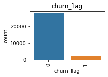

```python
plt.subplot(2,2,1)
plotFrequencyTable(df,'churn_flag')
```

Now, we shall remove all the columns that are corresponding to month 9 as it was used to derive the churn_flag column. This is done so that the top predictor columns are not the ones corresponding to month 9.

Explanation - variables not important anymore as predictor variables are needed to calculate churn for the target month 9

#### Removing all columns corresponding to month 9

```python
## Dropping columns pertaining to month 9
df = df.drop([col for col in df.columns if '9' in col], axis=1)
```

```python
## Checking if the remaining variables have missing values

missing = (df.isnull().sum() / len(df)) * 100
missing_df = pd.DataFrame({'Feature': df.columns,
                                 'missing (%)': missing})

missing_df
```

|  | Feature | missing (%) |
| --- | --- | --- |
| circle_id | circle_id | 0.0 |
| loc_og_t2o_mou | loc_og_t2o_mou | 0.0 |
| std_og_t2o_mou | std_og_t2o_mou | 0.0 |
| loc_ic_t2o_mou | loc_ic_t2o_mou | 0.0 |
| arpu_6 | arpu_6 | 0.0 |
| arpu_7 | arpu_7 | 0.0 |
| arpu_8 | arpu_8 | 0.0 |
| onnet_mou_6 | onnet_mou_6 | 0.0 |
| onnet_mou_7 | onnet_mou_7 | 0.0 |
| onnet_mou_8 | onnet_mou_8 | 0.0 |
| offnet_mou_6 | offnet_mou_6 | 0.0 |
| offnet_mou_7 | offnet_mou_7 | 0.0 |
| offnet_mou_8 | offnet_mou_8 | 0.0 |
| roam_ic_mou_6 | roam_ic_mou_6 | 0.0 |
| roam_ic_mou_7 | roam_ic_mou_7 | 0.0 |
| roam_ic_mou_8 | roam_ic_mou_8 | 0.0 |
| roam_og_mou_6 | roam_og_mou_6 | 0.0 |
| roam_og_mou_7 | roam_og_mou_7 | 0.0 |
| roam_og_mou_8 | roam_og_mou_8 | 0.0 |
| loc_og_t2t_mou_6 | loc_og_t2t_mou_6 | 0.0 |
| loc_og_t2t_mou_7 | loc_og_t2t_mou_7 | 0.0 |
| loc_og_t2t_mou_8 | loc_og_t2t_mou_8 | 0.0 |
| loc_og_t2m_mou_6 | loc_og_t2m_mou_6 | 0.0 |
| loc_og_t2m_mou_7 | loc_og_t2m_mou_7 | 0.0 |
| loc_og_t2m_mou_8 | loc_og_t2m_mou_8 | 0.0 |
| loc_og_t2f_mou_6 | loc_og_t2f_mou_6 | 0.0 |
| loc_og_t2f_mou_7 | loc_og_t2f_mou_7 | 0.0 |
| loc_og_t2f_mou_8 | loc_og_t2f_mou_8 | 0.0 |
| loc_og_t2c_mou_6 | loc_og_t2c_mou_6 | 0.0 |
| loc_og_t2c_mou_7 | loc_og_t2c_mou_7 | 0.0 |

[output cut: 138 more lines]

## #6 Exploratory Data Analysis (EDA)

Missing value treatment for the dataset has been done already as a part of data cleaning, we shall now proceed to perform outlier analysis.

### #6.1 Univariate and Bivariate Analysis of Columns

```python
# Analysis of the target variable
df['churn_flag'].value_counts(ascending=True)
```

```
1     2284
0    27737
Name: churn_flag, dtype: int64
```

[figure not shown]

```python
## Plot heatmap

# Let's see the correlation matrix
plt.figure(figsize = (20,10))        # Size of the figure
sns.heatmap(df.corr(),annot = True)
```

### #6.2 Outlier Analysis of the Data

```python
# Making a copy of the dataset
df_out = df.copy(deep = True)
```

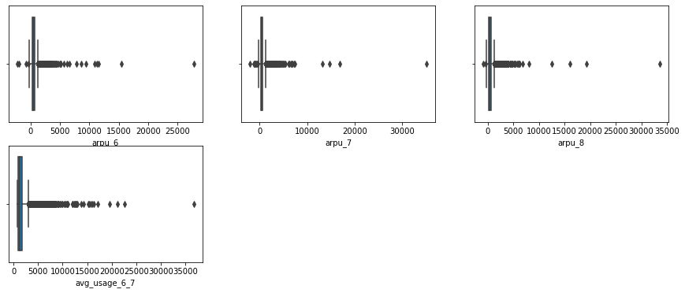

```python
# Making boxplots as sub-plots to understand the trend of the data
plt.figure(figsize=(15, 6))
plt.subplot(2,3,1)
sns.boxplot(x = 'arpu_6', data = df_out)
plt.subplot(2,3,2)
sns.boxplot(x = 'arpu_7', data = df_out)
plt.subplot(2,3,3)
sns.boxplot(x = 'arpu_8', data = df_out)
plt.subplot(2,3,4)
sns.boxplot(x = 'avg_usage_6_7', data = df_out)
```

```python
df_out.describe()
```

|  | circle_id | loc_og_t2o_mou | std_og_t2o_mou | loc_ic_t2o_mou | arpu_6 | arpu_7 | arpu_8 | onnet_mou_6 | onnet_mou_7 | onnet_mou_8 | offnet_mou_6 | offnet_mou_7 | offnet_mou_8 | roam_ic_mou_6 | roam_ic_mou_7 | roam_ic_mou_8 | roam_og_mou_6 | roam_og_mou_7 | roam_og_mou_8 | loc_og_t2t_mou_6 | loc_og_t2t_mou_7 | loc_og_t2t_mou_8 | loc_og_t2m_mou_6 | loc_og_t2m_mou_7 | loc_og_t2m_mou_8 | loc_og_t2f_mou_6 | loc_og_t2f_mou_7 | loc_og_t2f_mou_8 | loc_og_t2c_mou_6 | … |
| --- | --- | --- | --- | --- | --- | --- | --- | --- | --- | --- | --- | --- | --- | --- | --- | --- | --- | --- | --- | --- | --- | --- | --- | --- | --- | --- | --- | --- | --- | --- |
| count | 30021.0 | 30021.0 | 30021.0 | 30021.0 | 30021.000000 | 30021.000000 | 30021.000000 | 30021.000000 | 30021.000000 | 30021.000000 | 30021.000000 | 30021.000000 | 30021.000000 | 30021.000000 | 30021.000000 | 30021.000000 | 30021.000000 | 30021.000000 | 30021.000000 | 30021.000000 | 30021.000000 | 30021.000000 | 30021.000000 | 30021.000000 | 30021.000000 | 30021.000000 | 30021.000000 | 30021.000000 | 30021.000000 | … |
| mean | 109.0 | 0.0 | 0.0 | 0.0 | 533.955065 | 533.854002 | 486.199327 | 281.063655 | 287.425902 | 251.415043 | 389.015522 | 392.205523 | 343.998501 | 11.415742 | 8.216349 | 10.347790 | 16.611439 | 12.253223 | 15.236035 | 98.866527 | 98.813930 | 90.919323 | 174.222144 | 172.559275 | 160.401286 | 6.202958 | 6.285966 | 5.689884 | 1.553379 | … |
| std | 0.0 | 0.0 | 0.0 | 0.0 | 446.346800 | 469.749247 | 482.100951 | 470.494700 | 490.857755 | 466.338066 | 479.867119 | 497.048716 | 477.653703 | 60.828802 | 54.904593 | 62.385161 | 85.334915 | 67.534585 | 84.344336 | 253.897458 | 262.987239 | 248.333358 | 251.088799 | 242.536647 | 234.836768 | 21.700852 | 21.654945 | 18.742164 | 7.496119 | … |
| min | 109.0 | 0.0 | 0.0 | 0.0 | -2258.000000 | -2014.000000 | -945.000000 | -30.000000 | 0.000000 | -25.000000 | 0.000000 | 0.000000 | -42.000000 | 0.000000 | -2.000000 | -3.000000 | 0.000000 | 0.000000 | 0.000000 | -7.000000 | -23.000000 | -64.000000 | 0.000000 | 0.000000 | 0.000000 | 0.000000 | 0.000000 | 0.000000 | 0.000000 | … |
| 25% | 109.0 | 0.0 | 0.0 | 0.0 | 285.000000 | 280.000000 | 218.000000 | 25.000000 | 24.000000 | 18.000000 | 90.000000 | 86.000000 | 60.000000 | 0.000000 | 0.000000 | 0.000000 | 0.000000 | 0.000000 | 0.000000 | 6.000000 | 6.000000 | 5.000000 | 26.000000 | 26.000000 | 20.000000 | 0.000000 | 0.000000 | 0.000000 | 0.000000 | … |
| 50% | 109.0 | 0.0 | 0.0 | 0.0 | 451.000000 | 448.000000 | 400.000000 | 100.000000 | 98.000000 | 81.000000 | 243.000000 | 236.000000 | 196.000000 | 0.000000 | 0.000000 | 0.000000 | 0.000000 | 0.000000 | 0.000000 | 29.000000 | 29.000000 | 26.000000 | 89.000000 | 89.000000 | 77.000000 | 0.000000 | 0.000000 | 0.000000 | 0.000000 | … |
| 75% | 109.0 | 0.0 | 0.0 | 0.0 | 675.000000 | 675.000000 | 637.000000 | 325.000000 | 327.000000 | 268.000000 | 504.000000 | 509.000000 | 450.000000 | 0.000000 | 0.000000 | 0.000000 | 0.000000 | 0.000000 | 0.000000 | 92.000000 | 91.000000 | 85.000000 | 229.000000 | 227.000000 | 210.000000 | 4.000000 | 4.000000 | 4.000000 | 0.000000 | … |
| max | 109.0 | 0.0 | 0.0 | 0.0 | 27731.000000 | 35145.000000 | 33543.000000 | 7376.000000 | 8157.000000 | 10752.000000 | 8362.000000 | 9667.000000 | 14007.000000 | 2589.000000 | 2877.000000 | 2480.000000 | 3775.000000 | 1878.000000 | 3493.000000 | 6431.000000 | 7400.000000 | 10752.000000 | 4729.000000 | 4557.000000 | 4961.000000 | 1466.000000 | 1196.000000 | 928.000000 | 342.000000 | … |

```python
# Remove the outliers

def removeOutliers (dat, columnName):
    q1 = dat[columnName].quantile(0.01)
    q4 = dat[columnName].quantile(0.99)
    dat = dat[(dat[columnName]>=q1) & (dat[columnName]<=q4)]
    return dat
```

```python
# Removing the 99 percentile and and 1 percentile
columnNames = list(df.columns.values)

flag_col_names = ['arpu_6','arpu_7','arpu_8','avg_usage_6_7']

# targetColumnNames = list(set(columnNames) - set(flag_col_names))

for stringName in flag_col_names:
    df_out = removeOutliers(df_out, stringName)
```

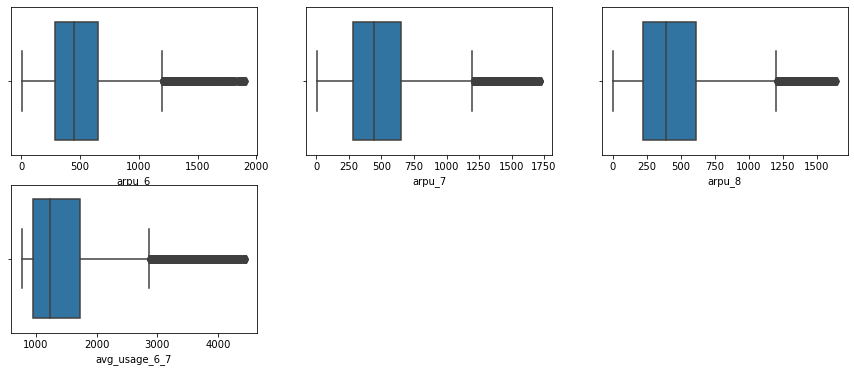

```python
# Making boxplots as sub-plots to understand the trend of the data
plt.figure(figsize=(15, 6))
plt.subplot(2,3,1)
sns.boxplot(x = 'arpu_6', data = df_out)
plt.subplot(2,3,2)
sns.boxplot(x = 'arpu_7', data = df_out)
plt.subplot(2,3,3)
sns.boxplot(x = 'arpu_8', data = df_out)
plt.subplot(2,3,4)
sns.boxplot(x = 'avg_usage_6_7', data = df_out)
```

```python
# df_out.to_csv("df_out.csv")
```

```python
# Checkpoint
# df_out= pd.read_csv("df_out.csv")
df = df_out.copy(deep = True)
```

```python
df.shape
```

```
(27931, 168)
```

## #7 Feature Scaling, Test-Train Split & Handling Class Imbalance in the data - SMOTE

```python
# Checkpoint for data
df_beforefeaturescaling = df.copy(deep = True)
```

```python
df_beforefeaturescaling.shape
```

```
(27931, 168)
```

```python
# Viewing the shape of the data
df.shape
```

```
(27931, 168)
```

```python
# Popping out high -value customer flag
df.pop('hvc_flag')

# Only one circle id
df.pop('circle_id')

# Separating the churn_flag Column
churn_flag = df.pop('churn_flag')
```

```python
df.shape
```

```
(27931, 165)
```

```python
# Viewing the head of the days
df.head()
```

|  | loc_og_t2o_mou | std_og_t2o_mou | loc_ic_t2o_mou | arpu_6 | arpu_7 | arpu_8 | onnet_mou_6 | onnet_mou_7 | onnet_mou_8 | offnet_mou_6 | offnet_mou_7 | offnet_mou_8 | roam_ic_mou_6 | roam_ic_mou_7 | roam_ic_mou_8 | roam_og_mou_6 | roam_og_mou_7 | roam_og_mou_8 | loc_og_t2t_mou_6 | loc_og_t2t_mou_7 | loc_og_t2t_mou_8 | loc_og_t2m_mou_6 | loc_og_t2m_mou_7 | loc_og_t2m_mou_8 | loc_og_t2f_mou_6 | loc_og_t2f_mou_7 | loc_og_t2f_mou_8 | loc_og_t2c_mou_6 | loc_og_t2c_mou_7 | … |
| --- | --- | --- | --- | --- | --- | --- | --- | --- | --- | --- | --- | --- | --- | --- | --- | --- | --- | --- | --- | --- | --- | --- | --- | --- | --- | --- | --- | --- | --- | --- |
| 0 | 0 | 0 | 0 | 429 | 190 | 255 | 71 | 45 | 76 | 262 | 49 | 92 | 0 | 0 | 0 | 0 | 0 | 0 | 71 | 45 | 76 | 252 | 48 | 80 | 10 | 0 | 0 | 0 | 0 | … |
| 1 | 0 | 0 | 0 | 378 | 492 | 137 | 413 | 351 | 35 | 94 | 80 | 136 | 0 | 0 | 0 | 0 | 0 | 0 | 297 | 217 | 12 | 80 | 70 | 50 | 0 | 0 | 0 | 0 | 0 | … |
| 2 | 0 | 0 | 0 | 492 | 205 | 593 | 501 | 108 | 534 | 413 | 119 | 482 | 23 | 144 | 72 | 7 | 35 | 1 | 49 | 6 | 36 | 151 | 47 | 294 | 4 | 0 | 23 | 0 | 0 | … |
| 3 | 0 | 0 | 0 | 514 | 597 | 637 | 102 | 132 | 85 | 757 | 896 | 983 | 0 | 0 | 0 | 0 | 0 | 0 | 4 | 6 | 23 | 91 | 87 | 104 | 0 | 0 | 1 | 0 | 0 | … |
| 4 | 0 | 0 | 0 | 422 | 359 | 354 | 124 | 55 | 141 | 450 | 370 | 283 | 9 | 0 | 13 | 9 | 0 | 22 | 43 | 20 | 2 | 219 | 185 | 72 | 12 | 18 | 20 | 3 | 0 | … |

```python
df.shape
```

```
(27931, 165)
```

```python
df_aftercleaningbeforetraintestsplit = df.copy(deep = True)
```

```python
# Splitting the dataset into dependent and independent features (X and y)
X = df
y = churn_flag
```

#### Splitting into train and test dataset

```python
# split into train and test
from sklearn.model_selection import train_test_split
X_train, X_test, y_train, y_test = train_test_split(X, y, train_size=0.7, test_size = 0.3, random_state=100)
```

```python
X_test.shape
```

```
(8380, 165)
```

```python
X_train.head()
```

|  | loc_og_t2o_mou | std_og_t2o_mou | loc_ic_t2o_mou | arpu_6 | arpu_7 | arpu_8 | onnet_mou_6 | onnet_mou_7 | onnet_mou_8 | offnet_mou_6 | offnet_mou_7 | offnet_mou_8 | roam_ic_mou_6 | roam_ic_mou_7 | roam_ic_mou_8 | roam_og_mou_6 | roam_og_mou_7 | roam_og_mou_8 | loc_og_t2t_mou_6 | loc_og_t2t_mou_7 | loc_og_t2t_mou_8 | loc_og_t2m_mou_6 | loc_og_t2m_mou_7 | loc_og_t2m_mou_8 | loc_og_t2f_mou_6 | loc_og_t2f_mou_7 | loc_og_t2f_mou_8 | loc_og_t2c_mou_6 | loc_og_t2c_mou_7 | … |
| --- | --- | --- | --- | --- | --- | --- | --- | --- | --- | --- | --- | --- | --- | --- | --- | --- | --- | --- | --- | --- | --- | --- | --- | --- | --- | --- | --- | --- | --- | --- |
| 2609 | 0 | 0 | 0 | 383 | 271 | 132 | 477 | 462 | 102 | 182 | 70 | 36 | 0 | 12 | 38 | 0 | 9 | 40 | 0 | 1 | 0 | 57 | 41 | 6 | 0 | 0 | 0 | 0 | 6 | … |
| 5584 | 0 | 0 | 0 | 313 | 725 | 190 | 105 | 816 | 275 | 175 | 280 | 216 | 0 | 0 | 0 | 0 | 0 | 0 | 62 | 42 | 40 | 72 | 32 | 36 | 18 | 78 | 42 | 0 | 0 | … |
| 7488 | 0 | 0 | 0 | 103 | 260 | 261 | 0 | 17 | 13 | 14 | 49 | 52 | 0 | 1 | 23 | 0 | 1 | 26 | 0 | 3 | 0 | 12 | 28 | 25 | 1 | 2 | 0 | 0 | 0 | … |
| 2062 | 0 | 0 | 0 | 549 | 518 | 623 | 199 | 299 | 478 | 1095 | 1301 | 1718 | 0 | 0 | 0 | 0 | 0 | 0 | 0 | 5 | 7 | 3 | 6 | 2 | 0 | 0 | 0 | 0 | 154 | … |
| 27252 | 0 | 0 | 0 | 459 | 391 | 272 | 108 | 156 | 112 | 511 | 322 | 487 | 0 | 26 | 0 | 0 | 33 | 0 | 108 | 134 | 112 | 408 | 286 | 392 | 54 | 6 | 15 | 0 | 5 | … |

#### Feature Scaling

Here we have normalize the continous variable while keeping the binary values intact separately for train and test datasets

```python
df_cont.shape
```

[output not shown]

```python
# Subsetting all the continous vairables for scaling
df = X_train
columnNames = list(df.columns.values)
flag_col_names = ['fb_user_8','fb_user_6','fb_user_7','fb_user_8','night_pck_user_6','night_pck_user_7','night_pck_user_8']
contColumnNames = list(set(columnNames) - set(flag_col_names))

# Creating df with continuous variables
df_cont = df[contColumnNames]

## Creating scaled dataframe for modelling
normalized_df=(df_cont-df_cont.mean())/df_cont.std()
df = df.drop(contColumnNames, 1)
df = pd.concat([df,normalized_df],axis=1)

# Dropping columns with only 0 values
df = df.drop(['std_og_t2c_mou_6','std_og_t2c_mou_8','std_og_t2o_mou','loc_ic_t2o_mou','std_ic_t2o_mou_8','std_ic_t2o_mou_6','loc_og_t2o_mou','std_ic_t2o_mou_7','std_og_t2c_mou_7'], 1)
df.head()

X_train = df
```

```python
X_train.shape
```

```
(19551, 156)
```

```python
# Subsetting all the continous vairables for scaling
df = X_test
columnNames = list(df.columns.values)
flag_col_names = ['fb_user_8','fb_user_6','fb_user_7','fb_user_8','night_pck_user_6','night_pck_user_7','night_pck_user_8']
contColumnNames = list(set(columnNames) - set(flag_col_names))

# Creating df with continuous variables
df_cont = df[contColumnNames]

## Creating scaled dataframe for modelling
normalized_df=(df_cont-df_cont.mean())/df_cont.std()
df = df.drop(contColumnNames, 1)
df = pd.concat([df,normalized_df],axis=1)

# Dropping columns with only 0 values
df = df.drop(['std_og_t2c_mou_6','std_og_t2c_mou_8','std_og_t2o_mou','loc_ic_t2o_mou','std_ic_t2o_mou_8','std_ic_t2o_mou_6','loc_og_t2o_mou','std_ic_t2o_mou_7','std_og_t2c_mou_7'], 1)
df.head()

X_test = df
```

#### Handling Class Imbalance using SMOTE Technique

```python
from imblearn.over_sampling import SMOTE

## check sampling strategy again
sm = SMOTE(random_state=100, sampling_strategy='minority')
X_train, y_train = sm.fit_sample(X_train, y_train)
```

```python
X_train.shape
```

```
(36352, 156)
```

```python
X_test.shape
```

```
(8380, 156)
```

## #8 Modelling - Part 1: Obtaining best churn classification

For Principal Component Analysis, we have already done the following to the data:

1. Missing Value Analysis
2. Outlier Analysis
3. Standardizing the data

## #8.1 PCA

```python
normalized_df = X_train
```

```python
# Importing required packages
from sklearn.decomposition import PCA
```

```python
# Instantiating an instance of PCA
pca = PCA(random_state=100)
```

```python
# Fitting the PCA instance on the normalized data
pca.fit(normalized_df)
```

```
PCA(copy=True, iterated_power='auto', n_components=None, random_state=100,
    svd_solver='auto', tol=0.0, whiten=False)
```

```python
# Viewing the PCA components
pca.components_.round(2)
```

```
array([[-0.  , -0.  , -0.  , ..., -0.04,  0.03, -0.  ],
       [ 0.  ,  0.  ,  0.  , ...,  0.11,  0.15, -0.  ],
       [ 0.  ,  0.  ,  0.  , ...,  0.04, -0.11, -0.  ],
       ...,
       [ 0.  ,  0.  , -0.  , ..., -0.  ,  0.  ,  0.  ],
       [-0.  ,  0.  , -0.  , ..., -0.  ,  0.  ,  0.  ],
       [ 0.  ,  0.  , -0.  , ...,  0.  ,  0.  , -0.  ]])
```

Let us now look at the explained variance ratio for the components

```python
# Plotting explained variance ratio
pca.explained_variance_ratio_.round(2)
```

```
array([0.12, 0.08, 0.07, 0.04, 0.04, 0.04, 0.04, 0.03, 0.02, 0.02, 0.02,
       0.02, 0.02, 0.02, 0.02, 0.02, 0.01, 0.01, 0.01, 0.01, 0.01, 0.01,
       0.01, 0.01, 0.01, 0.01, 0.01, 0.01, 0.01, 0.01, 0.01, 0.01, 0.01,
       0.01, 0.01, 0.01, 0.01, 0.01, 0.01, 0.01, 0.01, 0.01, 0.01, 0.  ,
       0.  , 0.  , 0.  , 0.  , 0.  , 0.  , 0.  , 0.  , 0.  , 0.  , 0.  ,
       0.  , 0.  , 0.  , 0.  , 0.  , 0.  , 0.  , 0.  , 0.  , 0.  , 0.  ,
       0.  , 0.  , 0.  , 0.  , 0.  , 0.  , 0.  , 0.  , 0.  , 0.  , 0.  ,
       0.  , 0.  , 0.  , 0.  , 0.  , 0.  , 0.  , 0.  , 0.  , 0.  , 0.  ,
       0.  , 0.  , 0.  , 0.  , 0.  , 0.  , 0.  , 0.  , 0.  , 0.  , 0.  ,
       0.  , 0.  , 0.  , 0.  , 0.  , 0.  , 0.  , 0.  , 0.  , 0.  , 0.  ,
       0.  , 0.  , 0.  , 0.  , 0.  , 0.  , 0.  , 0.  , 0.  , 0.  , 0.  ,
       0.  , 0.  , 0.  , 0.  , 0.  , 0.  , 0.  , 0.  , 0.  , 0.  , 0.  ,
       0.  , 0.  , 0.  , 0.  , 0.  , 0.  , 0.  , 0.  , 0.  , 0.  , 0.  ,
       0.  , 0.  , 0.  , 0.  , 0.  , 0.  , 0.  , 0.  , 0.  , 0.  , 0.  ,
       0.  , 0.  ])
```

We would like to explain about 80-90% of the variance in general when we use PCA, so this is a satisfactory result.

### #8.1.1 Standardizing the data

Train and test standardization has been already done (separately) as a part of data cleaning in the previous steps and can be accessed here:

- # Feature Scaling

### #8.1.2 PCA on the dataset

PCA has been performed on the data above

```python
# Plotting explained variance ratio
pca.explained_variance_ratio_.round(2)
```

```
array([0.12, 0.08, 0.07, 0.04, 0.04, 0.04, 0.04, 0.03, 0.02, 0.02, 0.02,
       0.02, 0.02, 0.02, 0.02, 0.02, 0.01, 0.01, 0.01, 0.01, 0.01, 0.01,
       0.01, 0.01, 0.01, 0.01, 0.01, 0.01, 0.01, 0.01, 0.01, 0.01, 0.01,
       0.01, 0.01, 0.01, 0.01, 0.01, 0.01, 0.01, 0.01, 0.01, 0.01, 0.  ,
       0.  , 0.  , 0.  , 0.  , 0.  , 0.  , 0.  , 0.  , 0.  , 0.  , 0.  ,
       0.  , 0.  , 0.  , 0.  , 0.  , 0.  , 0.  , 0.  , 0.  , 0.  , 0.  ,
       0.  , 0.  , 0.  , 0.  , 0.  , 0.  , 0.  , 0.  , 0.  , 0.  , 0.  ,
       0.  , 0.  , 0.  , 0.  , 0.  , 0.  , 0.  , 0.  , 0.  , 0.  , 0.  ,
       0.  , 0.  , 0.  , 0.  , 0.  , 0.  , 0.  , 0.  , 0.  , 0.  , 0.  ,
       0.  , 0.  , 0.  , 0.  , 0.  , 0.  , 0.  , 0.  , 0.  , 0.  , 0.  ,
       0.  , 0.  , 0.  , 0.  , 0.  , 0.  , 0.  , 0.  , 0.  , 0.  , 0.  ,
       0.  , 0.  , 0.  , 0.  , 0.  , 0.  , 0.  , 0.  , 0.  , 0.  , 0.  ,
       0.  , 0.  , 0.  , 0.  , 0.  , 0.  , 0.  , 0.  , 0.  , 0.  , 0.  ,
       0.  , 0.  , 0.  , 0.  , 0.  , 0.  , 0.  , 0.  , 0.  , 0.  , 0.  ,
       0.  , 0.  ])
```

### #8.1.3 Scree Plot

```python
# Let us take the cumulative variance of the explained variance ratios
var_cumu = np.cumsum(pca.explained_variance_ratio_)
```

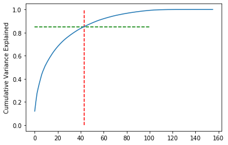

```python
# Plotting the scree plot with a mark on 95 percentile of variance being captured
fig = plt.figure(figsize=[6,4])
plt.vlines(x=43, ymax=1, ymin=0, colors="r", linestyles="--")
plt.hlines(y=0.85, xmax=100, xmin=0, colors="g", linestyles="--")
plt.plot(var_cumu)
plt.ylabel("Cumulative Variance Explained")
plt.show()
```

We now decide to do PCA with 43 (0 to 42 (both included) components as it explains a majority of the variance.

### #8.1.5 PCA Analysis

Incremental PCA with 43 components

```python
# importing Incremental PCA
from sklearn.decomposition import IncrementalPCA
```

```python
# Using 4 components to perform incremental PCA
pca_final = IncrementalPCA(n_components = 43)
```

```python
# Fitting and transforming the components on the normalized dataset
df_pca = pca_final.fit_transform(normalized_df)
```

```python
# Verifying that we have n_components = 4 (columns)
df_pca.shape
```

```
(36352, 43)
```

We can verify that the chosen features are uncorrelated with the help of a heatmap

```python
# Plotting the correlation matrix
corrmat = np.corrcoef(df_pca.transpose())
corrmat.shape
```

```
(43, 43)
```

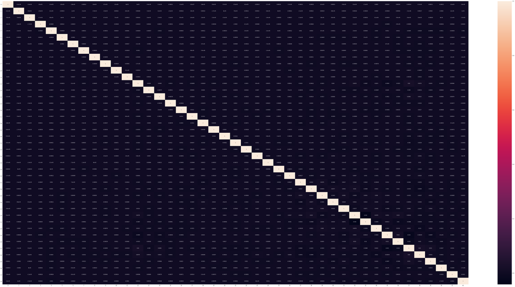

```python
# Plotting the heatmap
plt.figure(figsize=[100,50])
sns.heatmap(corrmat, annot=True)
```

Great, the chose PCA components are not correlated.

Now, let us make a dataframe from the 43 chosen components.

```python
# making a dataframe from the numpy array and naming the columns
df = pd.DataFrame(df_pca, columns=["PCA1", "PCA2", "PCA3", "PCA4", "PCA5", "PCA6", "PCA7", "PCA8", "PCA9", "PCA10",\
                                   "PCA11", "PCA12", "PCA13", "PCA14", "PCA15", "PCA16", "PCA17", "PCA18", "PCA19", "PCA20",\
                                   "PCA21", "PCA22", "PCA23", "PCA24", "PCA25", "PCA26", "PCA27", "PCA28", "PCA29", "PCA30",\
                                   "PCA31", "PCA32", "PCA33", "PCA34", "PCA35", "PCA36", "PCA37", "PCA38", "PCA39", "PCA40",\
                                   "PCA41", "PCA42", "PCA43"])
df.head()
```

|  | PCA1 | PCA2 | PCA3 | PCA4 | PCA5 | PCA6 | PCA7 | PCA8 | PCA9 | PCA10 | PCA11 | PCA12 | PCA13 | PCA14 | PCA15 | PCA16 | PCA17 | PCA18 | PCA19 | PCA20 | PCA21 | PCA22 | PCA23 | PCA24 | PCA25 | PCA26 | PCA27 | PCA28 | PCA29 | … |
| --- | --- | --- | --- | --- | --- | --- | --- | --- | --- | --- | --- | --- | --- | --- | --- | --- | --- | --- | --- | --- | --- | --- | --- | --- | --- | --- | --- | --- | --- | --- |
| 0 | -0.131328 | -3.232773 | 0.452767 | -0.113796 | 1.393617 | -0.736271 | -0.841512 | -0.353903 | -0.975497 | 0.203114 | -0.124354 | 0.366274 | -0.018065 | -0.280579 | -0.476299 | -0.140878 | -0.043190 | 0.117321 | -0.020667 | -0.653980 | -0.185472 | -0.234223 | -0.017070 | -0.150111 | -0.153289 | 0.477725 | -1.526331 | -0.453706 | -0.568657 | … |
| 1 | -1.588604 | 5.495942 | 0.674334 | -0.800954 | 2.439519 | -3.574296 | 2.303658 | -2.122252 | 2.030264 | 0.666976 | 0.717557 | 4.302165 | -0.659610 | -2.088865 | 1.773159 | 0.994349 | -0.603459 | -0.508720 | 1.830016 | 0.825326 | 3.517069 | 2.739911 | 0.636250 | -0.184805 | -0.755853 | -1.812218 | -0.439715 | -0.288178 | 0.952863 | … |
| 2 | -4.049243 | -2.371855 | 0.423902 | -0.134428 | 0.433366 | -2.111054 | -0.664768 | 0.358176 | 1.413354 | 0.784668 | 0.486776 | 2.530306 | 1.342016 | 2.801128 | -0.798358 | 1.184191 | -0.868856 | 0.768666 | -0.226439 | -0.744239 | 0.236281 | -0.252941 | -1.221493 | -1.037229 | -2.001007 | 0.112131 | -3.013366 | 0.667994 | 1.801531 | … |
| 3 | 7.585370 | 2.067806 | -2.466061 | -3.805847 | -5.498217 | -3.101748 | 4.615259 | -1.637420 | 1.174278 | -2.353929 | -1.028937 | -3.433462 | 14.692590 | -2.822380 | 6.346910 | -0.327122 | 3.445549 | -0.489372 | -1.996018 | -0.157007 | -0.017536 | 0.406070 | -1.804447 | 1.104743 | -0.344773 | -0.492030 | -1.504089 | 1.116110 | 0.078954 | … |
| 4 | -0.147018 | 0.124777 | 3.113612 | -0.104918 | -0.660441 | 0.290894 | -1.369105 | 0.703989 | -1.271785 | -1.390100 | -0.184678 | -0.268009 | 0.675188 | -0.731957 | -0.556273 | 0.090260 | -0.061348 | -0.234527 | 1.565260 | -0.068476 | 0.738884 | 0.238508 | 0.978423 | -0.546075 | -0.074128 | -0.550774 | -0.039516 | 0.112649 | -0.209197 | … |

```python
# Making a copy of the desired feature set
X_train_pca = df.copy(deep = True)
y_train_pca = y_train.copy(deep = True)
```

### #8.1.6 Making X_test_pca and y_test_pca

```python
# importing Incremental PCA
from sklearn.decomposition import IncrementalPCA
```

```python
# Using 4 components to perform incremental PCA
pca_final = IncrementalPCA(n_components = 43)
```

```python
normalized_df = X_test
```

```python
# Fitting and transforming the components on the normalized dataset
df_pca = pca_final.fit_transform(normalized_df)
```

```python
# Verifying that we have n_components = 43 (columns)
df_pca.shape
```

```
(8380, 43)
```

```python
# making a dataframe from the numpy array and naming the columns
df = pd.DataFrame(df_pca, columns=["PCA1", "PCA2", "PCA3", "PCA4", "PCA5", "PCA6", "PCA7", "PCA8", "PCA9", "PCA10",\
                                   "PCA11", "PCA12", "PCA13", "PCA14", "PCA15", "PCA16", "PCA17", "PCA18", "PCA19", "PCA20",\
                                   "PCA21", "PCA22", "PCA23", "PCA24", "PCA25", "PCA26", "PCA27", "PCA28", "PCA29", "PCA30",\
                                   "PCA31", "PCA32", "PCA33", "PCA34", "PCA35", "PCA36", "PCA37", "PCA38", "PCA39", "PCA40",\
                                   "PCA41", "PCA42", "PCA43"])
df.head()
```

|  | PCA1 | PCA2 | PCA3 | PCA4 | PCA5 | PCA6 | PCA7 | PCA8 | PCA9 | PCA10 | PCA11 | PCA12 | PCA13 | PCA14 | PCA15 | PCA16 | PCA17 | PCA18 | PCA19 | PCA20 | PCA21 | PCA22 | PCA23 | PCA24 | PCA25 | PCA26 | PCA27 | PCA28 | PCA29 | … |
| --- | --- | --- | --- | --- | --- | --- | --- | --- | --- | --- | --- | --- | --- | --- | --- | --- | --- | --- | --- | --- | --- | --- | --- | --- | --- | --- | --- | --- | --- | --- |
| 0 | 1.855634 | -0.761149 | 1.884832 | 0.248793 | -2.759667 | 1.391192 | 1.657797 | -2.248715 | -0.127492 | -2.293507 | 1.155426 | 0.742477 | -0.475942 | 0.370684 | 0.063604 | 0.054023 | -0.098124 | 0.298516 | -0.152326 | 0.481571 | -0.348141 | -0.038973 | 0.336115 | 0.459366 | -0.012121 | 0.198066 | 0.081755 | 0.824909 | -0.225742 | … |
| 1 | -6.904932 | 15.657176 | -7.490896 | -1.320677 | 1.507257 | 0.802230 | -2.701490 | -0.620964 | -1.855080 | -1.942614 | 1.192669 | 0.463976 | 0.227019 | -2.667283 | 3.135066 | 0.830905 | -0.446479 | 0.528195 | 1.216428 | -2.246777 | 0.688484 | 1.014636 | -1.478431 | -0.036042 | -0.169006 | 0.330149 | -0.590441 | 0.052893 | -0.948702 | … |
| 2 | 6.972801 | -0.232468 | -6.324585 | 1.107261 | 0.060511 | 5.115601 | 1.760841 | 0.587581 | -3.732336 | 2.628174 | -0.988089 | 0.253719 | 0.239664 | -1.453276 | 0.013536 | -0.356946 | -0.435420 | -0.934164 | -0.331168 | 0.997223 | -0.586346 | 0.040403 | -0.355940 | -0.640081 | 0.099606 | -0.327000 | 0.151597 | -0.357821 | -0.456127 | … |
| 3 | -4.826697 | -2.481232 | -3.156755 | 9.880329 | -0.313980 | -2.219583 | 1.659821 | -1.281328 | 2.016852 | 2.896610 | -1.051879 | -2.339597 | 0.474685 | -0.839487 | 1.336349 | 2.417848 | 2.118440 | -1.985197 | 0.634373 | 2.383713 | -0.707918 | -0.019222 | 0.573351 | 0.154804 | 0.073423 | -0.847873 | 0.105883 | -0.615229 | 0.329978 | … |
| 4 | 1.030521 | 1.080968 | 4.142679 | -0.096382 | 1.166841 | -3.499918 | 1.892206 | -2.253315 | -2.272143 | 3.764846 | -3.228209 | 0.139320 | 1.433006 | -0.786872 | -0.622079 | 0.840749 | 3.662545 | 3.611868 | -0.416129 | 0.332799 | -1.282679 | -0.747189 | -0.105064 | 0.984640 | 0.396272 | 2.447129 | -0.187717 | -1.674178 | -0.820230 | … |

```python
# Making a copy of the desired feature set
X_test_pca = df.copy(deep = True)
y_test_pca = y_test.copy(deep = True)
```

```python
print("X_train_pca shape:", X_train_pca.shape)
print("y_train_pca shape:", y_train_pca.shape)
print("X_test_pca shape:", X_test_pca.shape)
print("y_test_pca shape:", y_test_pca.shape)
```

```
X_train_pca shape: (36352, 43)
y_train_pca shape: (36352,)
X_test_pca shape: (8380, 43)
y_test_pca shape: (8380,)
```

```python
X_train_pca_backup = X_train_pca.copy(deep = True)
y_train_pca_backup = y_train_pca.copy(deep = True)
X_test_pca_backup = X_test_pca.copy(deep = True)
y_test_pca_backup = y_test_pca.copy(deep = True)
```

## #8.2 Algorithm 1: Logistic Regression + RFE

```python
# Checking the shape of the data
X_train_pca.shape
```

```
(36352, 43)
```

```python
# Importing the statsmodels package
import statsmodels.api as sm

# Logistic regression model
logreg = sm.GLM(y_train,(sm.add_constant(X_train_pca)), family = sm.families.Binomial())
logreg.fit().summary()
```

Generalized Linear Model Regression Results

| Dep. Variable: | churn_flag | No. Observations: | 36352 |
| --- | --- | --- | --- |
| Model: | GLM | Df Residuals: | 36308 |
| Model Family: | Binomial | Df Model: | 43 |
| Link Function: | logit | Scale: | 1.0000 |
| Method: | IRLS | Log-Likelihood: | -14205. |
| Date: | Sun, 17 May 2020 | Deviance: | 28410. |
| Time: | 20:02:24 | Pearson chi2: | 5.34e+04 |
| No. Iterations: | 8 |  |  |
| Covariance Type: | nonrobust |  |  |

|  | coef | std err | z | P>\|z\| | [0.025 | 0.975] |
| --- | --- | --- | --- | --- | --- | --- |
| const | -0.2153 | 0.017 | -12.587 | 0.000 | -0.249 | -0.182 |
| PCA1 | 0.1482 | 0.004 | 35.446 | 0.000 | 0.140 | 0.156 |
| PCA2 | -0.4478 | 0.006 | -71.245 | 0.000 | -0.460 | -0.435 |
| PCA3 | -0.1733 | 0.006 | -29.996 | 0.000 | -0.185 | -0.162 |
| PCA4 | 0.4687 | 0.007 | 62.678 | 0.000 | 0.454 | 0.483 |
| PCA5 | 0.2195 | 0.007 | 29.568 | 0.000 | 0.205 | 0.234 |
| PCA6 | 0.1326 | 0.008 | 16.205 | 0.000 | 0.117 | 0.149 |
| PCA7 | 0.0977 | 0.009 | 11.486 | 0.000 | 0.081 | 0.114 |
| PCA8 | -0.2393 | 0.009 | -25.944 | 0.000 | -0.257 | -0.221 |
| PCA9 | -0.1521 | 0.010 | -15.554 | 0.000 | -0.171 | -0.133 |
| PCA10 | 0.1625 | 0.010 | 16.128 | 0.000 | 0.143 | 0.182 |
| PCA11 | 0.4547 | 0.011 | 40.203 | 0.000 | 0.433 | 0.477 |
| PCA12 | 0.4709 | 0.012 | 39.754 | 0.000 | 0.448 | 0.494 |
| PCA13 | -0.0902 | 0.012 | -7.225 | 0.000 | -0.115 | -0.066 |
| PCA14 | -0.1683 | 0.012 | -14.456 | 0.000 | -0.191 | -0.145 |
| PCA15 | -0.0989 | 0.013 | -7.847 | 0.000 | -0.124 | -0.074 |
| PCA16 | 0.2296 | 0.012 | 18.531 | 0.000 | 0.205 | 0.254 |
| PCA17 | 0.2707 | 0.012 | 22.258 | 0.000 | 0.247 | 0.295 |
| PCA18 | -0.1305 | 0.014 | -9.584 | 0.000 | -0.157 | -0.104 |
| PCA19 | -0.0915 | 0.016 | -5.760 | 0.000 | -0.123 | -0.060 |
| PCA20 | -0.1376 | 0.014 | -9.817 | 0.000 | -0.165 | -0.110 |
| PCA21 | -0.0728 | 0.015 | -4.810 | 0.000 | -0.103 | -0.043 |
| PCA22 | -0.0389 | 0.016 | -2.484 | 0.013 | -0.070 | -0.008 |
| PCA23 | -0.0042 | 0.016 | -0.265 | 0.791 | -0.036 | 0.027 |
| PCA24 | 0.1221 | 0.017 | 7.209 | 0.000 | 0.089 | 0.155 |
| PCA25 | -0.1007 | 0.019 | -5.252 | 0.000 | -0.138 | -0.063 |
| PCA26 | -0.0525 | 0.016 | -3.183 | 0.001 | -0.085 | -0.020 |
| PCA27 | -0.1340 | 0.015 | -8.697 | 0.000 | -0.164 | -0.104 |
| PCA28 | 0.2224 | 0.020 | 11.368 | 0.000 | 0.184 | 0.261 |
| PCA29 | 0.2542 | 0.020 | 12.682 | 0.000 | 0.215 | 0.293 |
| PCA30 | 0.3081 | 0.018 | 16.677 | 0.000 | 0.272 | 0.344 |
| PCA31 | -0.0415 | 0.023 | -1.775 | 0.076 | -0.087 | 0.004 |
| PCA32 | 0.1627 | 0.019 | 8.740 | 0.000 | 0.126 | 0.199 |
| PCA33 | 0.0540 | 0.022 | 2.500 | 0.012 | 0.012 | 0.096 |
| PCA34 | -0.1288 | 0.022 | -5.838 | 0.000 | -0.172 | -0.086 |
| PCA35 | -0.0307 | 0.023 | -1.343 | 0.179 | -0.075 | 0.014 |
| PCA36 | 0.0162 | 0.022 | 0.750 | 0.453 | -0.026 | 0.058 |
| PCA37 | -0.4615 | 0.027 | -16.850 | 0.000 | -0.515 | -0.408 |
| PCA38 | 0.0660 | 0.021 | 3.098 | 0.002 | 0.024 | 0.108 |
| PCA39 | 0.0495 | 0.023 | 2.157 | 0.031 | 0.005 | 0.094 |
| PCA40 | 0.0124 | 0.028 | 0.443 | 0.658 | -0.042 | 0.067 |
| PCA41 | 0.2277 | 0.031 | 7.242 | 0.000 | 0.166 | 0.289 |
| PCA42 | -4.4961 | 0.406 | -11.082 | 0.000 | -5.291 | -3.701 |
| PCA43 | -3.3173 | 0.415 | -7.995 | 0.000 | -4.131 | -2.504 |

### Feature Selection Using RFE

```python
X_train_pca.shape
```

```
(36352, 43)
```

```python
# Importing the required packages and instantiating the logistic regression object
from sklearn.linear_model import LogisticRegression
logreg = LogisticRegression()
```

```python
# Fitting the model on the training dataset
logreg.fit(X_train_pca, y_train)

# Outputting the top 30 features
rfe = RFE(logreg, 30)
rfe = rfe.fit(X_train_pca, y_train)
```

```python
# listing the relevant features (obtained via Recursive Feature Elimination - RFE)
list(zip(X_train.columns,rfe.support_,rfe.ranking_))
```

```
[('night_pck_user_6', True, 1),
 ('night_pck_user_7', True, 1),
 ('night_pck_user_8', True, 1),
 ('fb_user_6', True, 1),
 ('fb_user_7', True, 1),
 ('fb_user_8', True, 1),
 ('max_rech_amt_8', True, 1),
 ('std_og_t2m_mou_7', True, 1),
 ('sachet_2g_6', True, 1),
 ('day_of_last_rech_8', True, 1),
 ('total_rech_num_8', True, 1),
 ('roam_ic_mou_7', True, 1),
 ('arpu_8', False, 3),
 ('week_of_last_rech_6', True, 1),
 ('sachet_2g_7', True, 1),
 ('isd_og_mou_7', True, 1),
 ('avg_usage_6_7', True, 1),
 ('isd_ic_mou_7', True, 1),
 ('std_ic_t2t_mou_6', True, 1),
 ('day_of_last_rech_7', True, 1),
 ('sep_vbc_3g', False, 5),
 ('vol_3g_mb_7', False, 11),
 ('spl_og_mou_6', False, 13),
 ('spl_og_mou_8', True, 1),
 ('arpu_2g_7', False, 2),
 ('offnet_mou_7', False, 6),
 ('spl_ic_mou_8', True, 1),
 ('count_rech_3g_6', True, 1),
 ('week_of_last_rech_8', True, 1),
 ('total_ic_mou_6', True, 1),
 ('std_og_t2f_mou_7', False, 10),
 ('arpu_3g_7', True, 1),
 ('week_of_last_rech_7', False, 8),
 ('total_usage_7', True, 1),
 ('loc_og_t2m_mou_8', False, 7),
 ('onnet_mou_6', False, 14),
 ('roam_og_mou_7', True, 1),
 ('loc_og_mou_8', False, 4),
 ('total_data_usage_7', False, 9),
 ('loc_og_t2t_mou_6', False, 12),
 ('std_ic_mou_6', True, 1),
 ('count_rech_3g_8', True, 1),
 ('jun_vbc_3g', True, 1)]
```

The features that say `False` can be given priority, with 1 being the highest, although RFE has implies that the features will not be as relevant for the model

```python
# The columns selected by RFE
col = X_train_pca.columns[rfe.support_]
col
```

```
Index(['PCA1', 'PCA2', 'PCA3', 'PCA4', 'PCA5', 'PCA6', 'PCA7', 'PCA8', 'PCA9',
       'PCA10', 'PCA11', 'PCA12', 'PCA14', 'PCA15', 'PCA16', 'PCA17', 'PCA18',
       'PCA19', 'PCA20', 'PCA24', 'PCA27', 'PCA28', 'PCA29', 'PCA30', 'PCA32',
       'PCA34', 'PCA37', 'PCA41', 'PCA42', 'PCA43'],
      dtype='object')
```

```python
# The columns that were not selected by RFE
X_train_pca.columns[~rfe.support_]
```

```
Index(['PCA13', 'PCA21', 'PCA22', 'PCA23', 'PCA25', 'PCA26', 'PCA31', 'PCA33',
       'PCA35', 'PCA36', 'PCA38', 'PCA39', 'PCA40'],
      dtype='object')
```

#### Building model using statsmodel, for the detailed statistics

### #8.2.2 Model Iterations - Logistic Regression + RFE

```python
import statsmodels.api as sm

# Creating X_train_rfe dataframe with RFE selected variables
X_train_rfe = X_train_pca[col]
```

```python
X_train_rfe = sm.add_constant(X_train_rfe)
logreg = sm.GLM(y_train,X_train_rfe, family = sm.families.Binomial())
res = logreg.fit()
res.summary()
```

Generalized Linear Model Regression Results

| Dep. Variable: | churn_flag | No. Observations: | 36352 |
| --- | --- | --- | --- |
| Model: | GLM | Df Residuals: | 36321 |
| Model Family: | Binomial | Df Model: | 30 |
| Link Function: | logit | Scale: | 1.0000 |
| Method: | IRLS | Log-Likelihood: | -14277. |
| Date: | Sun, 17 May 2020 | Deviance: | 28554. |
| Time: | 20:07:06 | Pearson chi2: | 5.45e+04 |
| No. Iterations: | 8 |  |  |
| Covariance Type: | nonrobust |  |  |

|  | coef | std err | z | P>\|z\| | [0.025 | 0.975] |
| --- | --- | --- | --- | --- | --- | --- |
| const | -0.1850 | 0.016 | -11.222 | 0.000 | -0.217 | -0.153 |
| PCA1 | 0.1485 | 0.004 | 35.601 | 0.000 | 0.140 | 0.157 |
| PCA2 | -0.4450 | 0.006 | -71.655 | 0.000 | -0.457 | -0.433 |
| PCA3 | -0.1717 | 0.006 | -30.615 | 0.000 | -0.183 | -0.161 |
| PCA4 | 0.4626 | 0.007 | 62.331 | 0.000 | 0.448 | 0.477 |
| PCA5 | 0.2145 | 0.007 | 29.184 | 0.000 | 0.200 | 0.229 |
| PCA6 | 0.1311 | 0.008 | 16.628 | 0.000 | 0.116 | 0.147 |
| PCA7 | 0.0926 | 0.008 | 11.351 | 0.000 | 0.077 | 0.109 |
| PCA8 | -0.2412 | 0.009 | -26.832 | 0.000 | -0.259 | -0.224 |
| PCA9 | -0.1472 | 0.010 | -15.318 | 0.000 | -0.166 | -0.128 |
| PCA10 | 0.1609 | 0.010 | 16.172 | 0.000 | 0.141 | 0.180 |
| PCA11 | 0.4516 | 0.011 | 41.016 | 0.000 | 0.430 | 0.473 |
| PCA12 | 0.4691 | 0.012 | 40.039 | 0.000 | 0.446 | 0.492 |
| PCA14 | -0.1717 | 0.011 | -15.285 | 0.000 | -0.194 | -0.150 |
| PCA15 | -0.0863 | 0.012 | -7.050 | 0.000 | -0.110 | -0.062 |
| PCA16 | 0.2218 | 0.012 | 18.470 | 0.000 | 0.198 | 0.245 |
| PCA17 | 0.2644 | 0.012 | 22.390 | 0.000 | 0.241 | 0.288 |
| PCA18 | -0.1273 | 0.013 | -9.520 | 0.000 | -0.154 | -0.101 |
| PCA19 | -0.0893 | 0.016 | -5.629 | 0.000 | -0.120 | -0.058 |
| PCA20 | -0.1364 | 0.014 | -9.772 | 0.000 | -0.164 | -0.109 |
| PCA24 | 0.1177 | 0.016 | 7.267 | 0.000 | 0.086 | 0.149 |
| PCA27 | -0.1371 | 0.015 | -9.059 | 0.000 | -0.167 | -0.107 |
| PCA28 | 0.2216 | 0.019 | 11.799 | 0.000 | 0.185 | 0.258 |
| PCA29 | 0.2294 | 0.019 | 11.973 | 0.000 | 0.192 | 0.267 |
| PCA30 | 0.3162 | 0.018 | 17.534 | 0.000 | 0.281 | 0.352 |
| PCA32 | 0.1690 | 0.018 | 9.177 | 0.000 | 0.133 | 0.205 |
| PCA34 | -0.1050 | 0.019 | -5.390 | 0.000 | -0.143 | -0.067 |
| PCA37 | -0.4344 | 0.024 | -17.986 | 0.000 | -0.482 | -0.387 |
| PCA41 | 0.1970 | 0.026 | 7.512 | 0.000 | 0.146 | 0.248 |
| PCA42 | -4.2915 | 0.273 | -15.710 | 0.000 | -4.827 | -3.756 |
| PCA43 | -1.7847 | 0.304 | -5.866 | 0.000 | -2.381 | -1.188 |

Here, we notice that the logistic regression model we have created along with Recursive Feature elimination has all p-values < 0.05, which is accepted.

Let us now look at the VIF Scores of the features selected.

### #8.2.3 Variance Inflation Factor (VIF)

```python
# Dropping the constant from the dataframe
X_train_rfe = X_train_rfe.drop(['const'], axis=1)
```

#### Iteration 1 - VIF, LogReg + RFE

```python
# Calculate the VIFs for the new model
from statsmodels.stats.outliers_influence import variance_inflation_factor

# Populating VIF values
vif = pd.DataFrame()
X = X_train_rfe
vif['Features'] = X.columns
vif['VIF'] = [variance_inflation_factor(X.values, i) for i in range(X.shape[1])]
vif['VIF'] = round(vif['VIF'], 2)
vif = vif.sort_values(by = "VIF", ascending = False)
vif
```

|  | Features | VIF |
| --- | --- | --- |
| 0 | PCA1 | 1.0 |
| 1 | PCA2 | 1.0 |
| 28 | PCA42 | 1.0 |
| 27 | PCA41 | 1.0 |
| 26 | PCA37 | 1.0 |
| 25 | PCA34 | 1.0 |
| 24 | PCA32 | 1.0 |
| 23 | PCA30 | 1.0 |
| 22 | PCA29 | 1.0 |
| 21 | PCA28 | 1.0 |
| 20 | PCA27 | 1.0 |
| 19 | PCA24 | 1.0 |
| 18 | PCA20 | 1.0 |
| 17 | PCA19 | 1.0 |
| 16 | PCA18 | 1.0 |
| 15 | PCA17 | 1.0 |
| 14 | PCA16 | 1.0 |
| 13 | PCA15 | 1.0 |
| 12 | PCA14 | 1.0 |
| 11 | PCA12 | 1.0 |
| 10 | PCA11 | 1.0 |
| 9 | PCA10 | 1.0 |
| 8 | PCA9 | 1.0 |
| 7 | PCA8 | 1.0 |
| 6 | PCA7 | 1.0 |
| 5 | PCA6 | 1.0 |
| 4 | PCA5 | 1.0 |
| 3 | PCA4 | 1.0 |
| 2 | PCA3 | 1.0 |
| 29 | PCA43 | 1.0 |

The VIP scores are in an acceptable range, hence, we do not need to handle anything here. All good!

```python
logreg = LogisticRegression()
X_train_rfe = sm.add_constant(X_train_rfe)
logreg.fit(X_train_rfe, y_train)

# Get accuracy percentage
logreg.score(X_train_rfe, y_train)
```

```
0.841796875
```

### #8.2.4 Residual Analysis of Train Data

So, now to check if the error terms are also normally distributed (which is infact, one of the major assumptions of linear regression), let us plot the histogram of the error terms and see what it looks like.

```python
y_train_churn = logreg.predict(X_train_rfe)
```

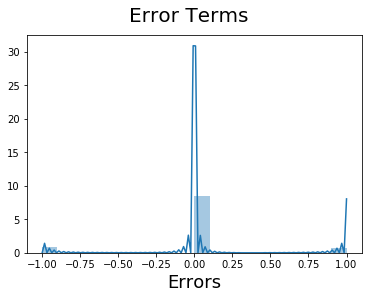

```python
# Plot the histogram of the error terms
fig = plt.figure()
sns.distplot((y_train - y_train_churn), bins = 20)
fig.suptitle('Error Terms', fontsize = 20)                  # Plot heading
plt.xlabel('Errors', fontsize = 18)                         # X-label
```

```python
# Dropping the constant from the dataframe
X_train_rfe = X_train_rfe.drop(['const'], axis=1)
```

### #8.2.5 Making Predictions - Test Data (LogReg + RFE + VIF)

```python
# Now let's use our model to make predictions.

# Creating X_test_new dataframe by dropping variables from X_test
X_test_new = X_test_pca[X_train_rfe.columns]

# Adding a constant variable
X_test_new = sm.add_constant(X_test_new)
```

```python
# Adding constant
X_train_rfe = sm.add_constant(X_train_rfe)

#Viewing the shape of the
X_train_rfe.shape
```

```
(36352, 31)
```

```python
# Viewing the shape of the test data
X_test_new.shape
```

```
(8380, 31)
```

##### Score of Train Data: 84.18%

```python
# Viweing the score of the Test Data
round(logreg.score(X_train_rfe, y_train_pca)*100,2)
```

```
84.18
```

```python
X_test_new.shape
```

```
(8380, 31)
```

```python
# Viweing the score of the Test Data
round(logreg.score(X_test_new, y_test_pca),4)*100
```

```
47.96
```

### #8.2.6 Analysis of Results - Sensitivity and Type 2 Error: PCA + LogReg + VIF

```python
from sklearn.metrics import confusion_matrix
```

```python
y_predicted = logreg.predict(X_test_new)
y_actual = y_test
print(confusion_matrix(y_actual, y_predicted))
```

```
[[3781 4015]
 [ 293  291]]
```

```python
# False Positive and False Negative
cm =confusion_matrix(y_actual, y_predicted)

TP = confusion_matrix(y_actual, y_predicted)[0][0]
FP = confusion_matrix(y_actual, y_predicted)[0][1]
FN = confusion_matrix(y_actual, y_predicted)[1][0]
TN = confusion_matrix(y_actual, y_predicted)[1][1]
total=sum(sum(cm))

print( " False Positive (Type I Error): ", FP)
print( " False Negative (Type II Error): ", FN)

# Accuracy
accuracy = round(100 - ((FP + FN)* 100 / len(y_predicted)),2)
print( "Accuracy: ", round(accuracy,2), '%')

# Sensitivity
sensitivity = round(TP*100 / (TP + FP),2)
print( "Sensitivity: ", sensitivity, '%')
```

```
 False Positive (Type I Error):  4015
 False Negative (Type II Error):  293
Accuracy:  48.59 %
Sensitivity:  48.5 %
```

Here, we clearly see that this is not a great algorithm.

## #8.3 Algorithm 2: Random Forest

```python
# Importing random forest classifier from sklearn library
from sklearn.ensemble import RandomForestClassifier

# Running the random forest with default parameters.
rfc = RandomForestClassifier()
```

```python
# fit
rfc.fit(X_train_pca,y_train_pca)
```

```
RandomForestClassifier(bootstrap=True, ccp_alpha=0.0, class_weight=None,
                       criterion='gini', max_depth=None, max_features='auto',
                       max_leaf_nodes=None, max_samples=None,
                       min_impurity_decrease=0.0, min_impurity_split=None,
                       min_samples_leaf=1, min_samples_split=2,
                       min_weight_fraction_leaf=0.0, n_estimators=100,
                       n_jobs=None, oob_score=False, random_state=None,
                       verbose=0, warm_start=False)
```

### #8.3.1 Analysis of Feature to be predicted

```python
# Making predictions
predictions = rfc.predict(X_test_pca)
```

```python
# Importing classification report and confusion matrix from sklearn metrics
from sklearn.metrics import classification_report,confusion_matrix, accuracy_score
```

```python
# Let's check the report of our default model
print(classification_report(y_test_pca,predictions))
```

```
              precision    recall  f1-score   support

           0       0.93      0.98      0.95      7796
           1       0.08      0.03      0.05       584

    accuracy                           0.91      8380
   macro avg       0.51      0.50      0.50      8380
weighted avg       0.87      0.91      0.89      8380
```

```python
# Printing confusion matrix
print(confusion_matrix(y_test,predictions))
```

```
[[7602  194]
 [ 566   18]]
```

```python
print(round(accuracy_score(y_test,predictions)*100, 2),'%')
```

```
90.93 %
```

### #8.3.2 Hyperparameter Tuning

The following hyperparameters are present in a random forest classifier. Note that most of these hypereparameters are actually of the decision trees that are in the forest.

- **n_estimators**: integer, optional (default=10): The number of trees in the forest.
- **criterion**: string, optional (default=”gini”)The function to measure the quality of a split. Supported criteria are “gini” for the Gini impurity and “entropy” for the information gain. Note: this parameter is tree-specific.
- **max_features** : int, float, string or None, optional (default=”auto”)The number of features to consider when looking for the best split:
  - If int, then consider max_features features at each split.
  - If float, then max_features is a percentage and int(max_features * n_features) features are considered at each split.
  - If “auto”, then max_features=sqrt(n_features).
  - If “sqrt”, then max_features=sqrt(n_features) (same as “auto”).
  - If “log2”, then max_features=log2(n_features).
  - If None, then max_features=n_features.
  - Note: the search for a split does not stop until at least one valid partition of the node samples is found, even if it requires to effectively inspect more than max_features features.
- **max_depth** : integer or None, optional (default=None)The maximum depth of the tree. If None, then nodes are expanded until all leaves are pure or until all leaves contain less than min_samples_split samples.
- **min_samples_split** : int, float, optional (default=2)The minimum number of samples required to split an internal node:**
  - **If int, then consider min_samples_split as the minimum number.
  - **If float, then min_samples_split is a percentage and ceil(min_samples_split, n_samples) are the minimum number of samples for each split.
- **min_samples_leaf** : int, float, optional (default=1)The minimum number of samples required to be at a leaf node:**
  - **If int, then consider min_samples_leaf as the minimum number.**
  - **If float, then min_samples_leaf is a percentage and ceil(min_samples_leaf * n_samples) are the minimum number of samples for each node.**
- **min_weight_fraction_leaf** : float, optional (default=0.)The minimum weighted fraction of the sum total of weights (of all the input samples) required to be at a leaf node. Samples have equal weight when sample_weight is not provided.
- **max_leaf_nodes** : int or None, optional (default=None)Grow trees with max_leaf_nodes in best-first fashion. Best nodes are defined as relative reduction in impurity. If None then unlimited number of leaf nodes.
- **min_impurity_split** : float,Threshold for early stopping in tree growth. A node will split if its impurity is above the threshold, otherwise it is a leaf.

### Tuning max_depth

Let's try to find the optimum values for `max_depth` and understand how the value of max_depth impacts the overall accuracy of the ensemble.

```python
# GridSearchCV to find optimal n_estimators
from sklearn.model_selection import KFold
from sklearn.model_selection import GridSearchCV


# specify number of folds for k-fold CV
n_folds = 5

# parameters to build the model on
parameters = {'max_depth': range(2, 20, 5)}

# instantiate the model
rf = RandomForestClassifier()


# fit tree on training data
rf = GridSearchCV(rf, parameters,
                    cv=n_folds,
                   scoring="accuracy")
rf.fit(X_train_pca, y_train_pca)
```

```
GridSearchCV(cv=5, error_score=nan,
             estimator=RandomForestClassifier(bootstrap=True, ccp_alpha=0.0,
                                              class_weight=None,
                                              criterion='gini', max_depth=None,
                                              max_features='auto',
                                              max_leaf_nodes=None,
                                              max_samples=None,
                                              min_impurity_decrease=0.0,
                                              min_impurity_split=None,
                                              min_samples_leaf=1,
                                              min_samples_split=2,
                                              min_weight_fraction_leaf=0.0,
                                              n_estimators=100, n_jobs=None,
                                              oob_score=False,
                                              random_state=None, verbose=0,
                                              warm_start=False),
             iid='deprecated', n_jobs=None,
             param_grid={'max_depth': range(2, 20, 5)}, pre_dispatch='2*n_jobs',
             refit=True, return_train_score=False, scoring='accuracy',
             verbose=0)
```

```python
# scores of GridSearch CV
scores = rf.cv_results_
pd.DataFrame(scores).head()
```

|  | mean_fit_time | std_fit_time | mean_score_time | std_score_time | param_max_depth | params | split0_test_score | split1_test_score | split2_test_score | split3_test_score | split4_test_score | mean_test_score | std_test_score | rank_test_score |
| --- | --- | --- | --- | --- | --- | --- | --- | --- | --- | --- | --- | --- | --- | --- |
| 0 | 3.833305 | 0.186107 | 0.059094 | 0.006796 | 2 | {'max_depth': 2} | 0.755604 | 0.783799 | 0.788996 | 0.785282 | 0.787208 | 0.780178 | 0.012411 | 4 |
| 1 | 11.750924 | 0.898757 | 0.133059 | 0.032191 | 7 | {'max_depth': 7} | 0.857241 | 0.868794 | 0.871389 | 0.872765 | 0.867813 | 0.867600 | 0.005474 | 3 |
| 2 | 18.492654 | 0.354037 | 0.176686 | 0.025305 | 12 | {'max_depth': 12} | 0.933847 | 0.933847 | 0.932737 | 0.935076 | 0.930949 | 0.933291 | 0.001385 | 2 |
| 3 | 22.731519 | 1.385568 | 0.201476 | 0.033209 | 17 | {'max_depth': 17} | 0.956815 | 0.953789 | 0.954058 | 0.955296 | 0.950894 | 0.954170 | 0.001957 | 1 |

```python
pd.DataFrame(scores).shape
```

```
(4, 14)
```

[figure not shown]

```python
# plotting accuracies with max_depth
plt.figure()
plt.plot(scores["param_max_depth"],
         scores["mean_train_score"],
         label="training accuracy")
plt.plot(scores["param_max_depth"],
         scores["mean_test_score"],
         label="test accuracy")
plt.xlabel("max_depth")
plt.ylabel("Accuracy")
plt.legend()
plt.show()
```

### Tuning n_estimators

Let's try to find the optimum values for n_estimators and understand how the value of n_estimators impacts the overall accuracy. Notice that we'll specify an appropriately low value of max_depth, so that the trees do not overfit.

```python
# GridSearchCV to find optimal n_estimators
from sklearn.model_selection import KFold
from sklearn.model_selection import GridSearchCV


# specify number of folds for k-fold CV
n_folds = 5

# parameters to build the model on
parameters = {'n_estimators': range(100, 1500, 400)}

# instantiate the model (note we are specifying a max_depth)
rf = RandomForestClassifier(max_depth=4)


# fit tree on training data
rf = GridSearchCV(rf, parameters,
                    cv=n_folds,
                   scoring="accuracy")
rf.fit(X_train_pca, y_train_pca)
```

```
GridSearchCV(cv=5, error_score=nan,
             estimator=RandomForestClassifier(bootstrap=True, ccp_alpha=0.0,
                                              class_weight=None,
                                              criterion='gini', max_depth=4,
                                              max_features='auto',
                                              max_leaf_nodes=None,
                                              max_samples=None,
                                              min_impurity_decrease=0.0,
                                              min_impurity_split=None,
                                              min_samples_leaf=1,
                                              min_samples_split=2,
                                              min_weight_fraction_leaf=0.0,
                                              n_estimators=100, n_jobs=None,
                                              oob_score=False,
                                              random_state=None, verbose=0,
                                              warm_start=False),
             iid='deprecated', n_jobs=None,
             param_grid={'n_estimators': range(100, 1500, 400)},
             pre_dispatch='2*n_jobs', refit=True, return_train_score=False,
             scoring='accuracy', verbose=0)
```

```python
# scores of GridSearch CV
scores = rf.cv_results_
pd.DataFrame(scores).head()
```

|  | mean_fit_time | std_fit_time | mean_score_time | std_score_time | param_n_estimators | params | split0_test_score | split1_test_score | split2_test_score | split3_test_score | split4_test_score | mean_test_score | std_test_score | rank_test_score |
| --- | --- | --- | --- | --- | --- | --- | --- | --- | --- | --- | --- | --- | --- | --- |
| 0 | 7.880269 | 0.563534 | 0.079603 | 0.011776 | 100 | {'n_estimators': 100} | 0.812543 | 0.823821 | 0.827923 | 0.827510 | 0.819945 | 0.822348 | 0.005689 | 4 |
| 1 | 38.377262 | 1.222143 | 0.437888 | 0.067645 | 500 | {'n_estimators': 500} | 0.812818 | 0.825609 | 0.827648 | 0.832050 | 0.820770 | 0.823779 | 0.006571 | 3 |
| 2 | 65.695449 | 3.640723 | 0.706085 | 0.075815 | 900 | {'n_estimators': 900} | 0.810755 | 0.829597 | 0.827648 | 0.831087 | 0.826823 | 0.825182 | 0.007366 | 1 |
| 3 | 94.955054 | 6.310093 | 1.102096 | 0.101584 | 1300 | {'n_estimators': 1300} | 0.811718 | 0.825884 | 0.827235 | 0.833287 | 0.823796 | 0.824384 | 0.007077 | 2 |

### #8.3.3 Grid Search

We can now find the optimal hyperparameters using GridSearchCV.

```python
# Create the parameter grid based on the results of random search
param_grid = {
    'max_depth': [4,8,10],
    'min_samples_leaf': range(100, 400, 200),
    'min_samples_split': range(200, 500, 200),
    'n_estimators': [100,200, 300],
    'max_features': [5, 10]
}
# Create a based model
rf = RandomForestClassifier()
# Instantiate the grid search model
grid_search = GridSearchCV(estimator = rf, param_grid = param_grid,
                          cv = 3, n_jobs = -1,verbose = 1)
```

```python
# Fit the grid search to the data
grid_search.fit(X_train_pca, y_train_pca)
```

```
Fitting 3 folds for each of 72 candidates, totalling 216 fits
```

```
[Parallel(n_jobs=-1)]: Using backend LokyBackend with 4 concurrent workers.
[Parallel(n_jobs=-1)]: Done  42 tasks      | elapsed:  3.7min
[Parallel(n_jobs=-1)]: Done 192 tasks      | elapsed: 25.2min
[Parallel(n_jobs=-1)]: Done 216 out of 216 | elapsed: 29.5min finished
```

```
GridSearchCV(cv=3, error_score=nan,
             estimator=RandomForestClassifier(bootstrap=True, ccp_alpha=0.0,
                                              class_weight=None,
                                              criterion='gini', max_depth=None,
                                              max_features='auto',
                                              max_leaf_nodes=None,
                                              max_samples=None,
                                              min_impurity_decrease=0.0,
                                              min_impurity_split=None,
                                              min_samples_leaf=1,
                                              min_samples_split=2,
                                              min_weight_fraction_leaf=0.0,
                                              n_estimators=100, n_jobs=None,
                                              oob_score=False,
                                              random_state=None, verbose=0,
                                              warm_start=False),
             iid='deprecated', n_jobs=-1,
             param_grid={'max_depth': [4, 8, 10], 'max_features': [5, 10],
                         'min_samples_leaf': range(100, 400, 200),
                         'min_samples_split': range(200, 500, 200),
                         'n_estimators': [100, 200, 300]},
             pre_dispatch='2*n_jobs', refit=True, return_train_score=False,
             scoring=None, verbose=1)
```

```python
# printing the optimal accuracy score and hyperparameters
print('We can get accuracy of',grid_search.best_score_,'using',grid_search.best_params_)
```

```
We can get accuracy of 0.8609432172134347 using {'max_depth': 10, 'max_features': 10, 'min_samples_leaf': 100, 'min_samples_split': 200, 'n_estimators': 200}
```

```python
# model with the best hyperparameters
from sklearn.ensemble import RandomForestClassifier
rfc = RandomForestClassifier(bootstrap=True,
                             max_depth=10,
                             min_samples_leaf=100,
                             min_samples_split=200,
                             max_features=10,
                             n_estimators=100)
```

```python
# fit
rfc.fit(X_train_pca,y_train_pca)
```

```
RandomForestClassifier(bootstrap=True, ccp_alpha=0.0, class_weight=None,
                       criterion='gini', max_depth=10, max_features=10,
                       max_leaf_nodes=None, max_samples=None,
                       min_impurity_decrease=0.0, min_impurity_split=None,
                       min_samples_leaf=100, min_samples_split=200,
                       min_weight_fraction_leaf=0.0, n_estimators=100,
                       n_jobs=None, oob_score=False, random_state=None,
                       verbose=0, warm_start=False)
```

```python
# predict
predictions = rfc.predict(X_test_pca)
```

```python
# evaluation metrics
from sklearn.metrics import classification_report,confusion_matrix
```

```python
print(classification_report(y_test_pca,predictions))
```

```
              precision    recall  f1-score   support

           0       0.93      0.67      0.78      7796
           1       0.08      0.36      0.13       584

    accuracy                           0.65      8380
   macro avg       0.50      0.52      0.45      8380
weighted avg       0.87      0.65      0.74      8380
```

```python
print(confusion_matrix(y_test_pca,predictions))
```

```
[[5239 2557]
 [ 373  211]]
```

### #8.3.4 Analysis of Results - Sensitivity and Type 2 Error: PCA + Random Forest + Grid Search

```python
from sklearn.metrics import confusion_matrix
```

```python
y_predicted = predictions
y_actual = y_test_pca
print(confusion_matrix(y_test_pca, y_predicted))
```

```
[[5239 2557]
 [ 373  211]]
```

```python
# False Positive and False Negative
cm =confusion_matrix(y_actual, y_predicted)

TP = confusion_matrix(y_actual, y_predicted)[0][0]
FP = confusion_matrix(y_actual, y_predicted)[0][1]
FN = confusion_matrix(y_actual, y_predicted)[1][0]
TN = confusion_matrix(y_actual, y_predicted)[1][1]
total=sum(sum(cm))

print( " False Positive (Type I Error): ", FP)
print( " False Negative (Type II Error): ", FN)

# Accuracy
accuracy = round(100 - ((FP + FN)* 100 / len(y_predicted)),2)
print( "Accuracy: ", round(accuracy,2), '%')

# Sensitivity
sensitivity = round(TP*100 / (TP + FP),2)
print( "Sensitivity: ", sensitivity, '%')
```

```
 False Positive (Type I Error):  2557
 False Negative (Type II Error):  373
Accuracy:  65.04 %
Sensitivity:  67.2 %
```

Given that this is a classification analysis, the way to evaluate the method will be dependent on the business problem.

If we analyze the customer churn problem, the aim is to stop customers before they churn away from the service provider. Here, a way of looking the success criteria is two-fold as follows:

- **Minimize Type II Error:** This means that we should try to minimize missing out on cutomers who can leave and we did not identify. It is okay here to have a higher Type I error as we might end up targeting customers who are not in risk of shurn and this will not affect the telecom service provider as much
- **Maximize Sensitivity:** Sensitivity is an indicator of the True Positive Rate. Here, the aim is to get as many customers who might churn as possible, the higher this is, it is a better indicator of our problem

## #8.4 Algorithm 3: Support Vector Machine

### #8.4.1 Running default Support Vector Mchine

```python
# Support Vector Machines
from sklearn.svm import SVC
svc = SVC()

# Fitting SVC with default parameters
svc.fit(X_train_pca, y_train_pca)
```

```
SVC(C=1.0, break_ties=False, cache_size=200, class_weight=None, coef0=0.0,
    decision_function_shape='ovr', degree=3, gamma='scale', kernel='rbf',
    max_iter=-1, probability=False, random_state=None, shrinking=True,
    tol=0.001, verbose=False)
```

```python
# Obtaining the predictions of the SVC model that has been fit
y_pred = svc.predict(X_test_pca)
```

```python
# Analysis of score on Train Data
svc.score(X_train_pca, y_train_pca)
```

```
0.9216549295774648
```

```python
# Analysis of score on Test data
svc.score(X_test_pca, y_test_pca)
```

```
0.6374701670644392
```

### #8.4.2 Hyperparameter tuning via GridSearch CV

```python
# Importing required model for Grid Search
from sklearn.model_selection import GridSearchCV
```

```python
# Parameters to iterate through to decide best C, gamma and kernel values
param_grid = {'C': [0.5,1, 10, 100], 'gamma': [1,0.1],'kernel': ['rbf', 'poly', 'sigmoid']}
```

```python
# GridSearch CV through the iterated values
grid = GridSearchCV(SVC(),param_grid,refit=True,verbose=2)
grid.fit(X_train_pca, y_train_pca)
```

```
Fitting 5 folds for each of 24 candidates, totalling 120 fits
[CV] C=0.5, gamma=1, kernel=rbf ......................................
```

```
[Parallel(n_jobs=1)]: Using backend SequentialBackend with 1 concurrent workers.
```

```
[CV] ....................... C=0.5, gamma=1, kernel=rbf, total= 3.8min
[CV] C=0.5, gamma=1, kernel=rbf ......................................
```

```
[Parallel(n_jobs=1)]: Done   1 out of   1 | elapsed:  3.8min remaining:    0.0s
```

[output not shown]

[output cut: 182 more lines]

[output not shown]

```
[Parallel(n_jobs=1)]: Done 120 out of 120 | elapsed: 490.7min finished
```

```
GridSearchCV(cv=None, error_score=nan,
             estimator=SVC(C=1.0, break_ties=False, cache_size=200,
                           class_weight=None, coef0=0.0,
                           decision_function_shape='ovr', degree=3,
                           gamma='scale', kernel='rbf', max_iter=-1,
                           probability=False, random_state=None, shrinking=True,
                           tol=0.001, verbose=False),
             iid='deprecated', n_jobs=None,
             param_grid={'C': [0.5, 1, 10, 100], 'gamma': [1, 0.1],
                         'kernel': ['rbf', 'poly', 'sigmoid']},
             pre_dispatch='2*n_jobs', refit=True, return_train_score=False,
             scoring=None, verbose=2)
```

```python
# Printing the best parameters from the Grid Search
print(grid.best_estimator_)
```

```
SVC(C=10, break_ties=False, cache_size=200, class_weight=None, coef0=0.0,
    decision_function_shape='ovr', degree=3, gamma=0.1, kernel='rbf',
    max_iter=-1, probability=False, random_state=None, shrinking=True,
    tol=0.001, verbose=False)
```

Hence, the optimal parameters are as follows:

- C = 10
- Gamma = 0.1
- Kernel = 'rbf'

```python
# Observing the shape of y_test_pca
y_test_pca.shape
```

```
(8380,)
```

```python
# Performing predictions on the test data
grid_predictions = grid.predict(X_test_pca)
print(confusion_matrix(y_test_pca,grid_predictions))
print(classification_report(y_test_pca,grid_predictions))
```

```
[[7735   61]
 [ 582    2]]
              precision    recall  f1-score   support

           0       0.93      0.99      0.96      7796
           1       0.03      0.00      0.01       584

    accuracy                           0.92      8380
   macro avg       0.48      0.50      0.48      8380
weighted avg       0.87      0.92      0.89      8380
```

### #8.4.3 Analysis of Results - Sensitivity and Type 2 Error: PCA + Support Vector Machine + Grid Search

```python
from sklearn.metrics import confusion_matrix
```

```python
# Obtaining the confusion matrix
y_predicted = grid_predictions
y_actual = y_test_pca
print(confusion_matrix(y_actual, y_predicted))
```

```
[[7735   61]
 [ 582    2]]
```

```python
# False Positive and False Negative
cm =confusion_matrix(y_actual, y_predicted)

# Obtaining TP, TN, FP, FN values from the confusion matrix
TP = confusion_matrix(y_actual, y_predicted)[0][0]
FP = confusion_matrix(y_actual, y_predicted)[0][1]
FN = confusion_matrix(y_actual, y_predicted)[1][0]
TN = confusion_matrix(y_actual, y_predicted)[1][1]
total=sum(sum(cm))

# Printing the results
print( " False Positive (Type I Error): ", FP)
print( " False Negative (Type II Error): ", FN)

# Accuracy
accuracy = round(100 - ((FP + FN)* 100 / len(y_predicted)),2)
print( "Accuracy: ", round(accuracy,2), '%')

# Sensitivity
sensitivity = round(TP*100 / (TP + FP),2)
print( "Sensitivity: ", sensitivity, '%')
```

```
 False Positive (Type I Error):  61
 False Negative (Type II Error):  582
Accuracy:  92.33 %
Sensitivity:  99.22 %
```

Here, we notice that **Support Vector machines** has given us some to of the best results:

Given that this is a classification analysis, the way to evaluate the method will be dependent on the business problem.

If we analyze the customer churn problem, the aim is to stop customers before they churn away from the service provider. Here, a way of looking the success criteria is two-fold as follows:

- **Minimize Type II Error:** This means that we should try to minimize missing out on cutomers who can leave and we did not identify. It is okay here to have a higher Type I error as we might end up targeting customers who are not in risk of shurn and this will not affect the telecom service provider as much
- **Maximize Sensitivity:** Sensitivity is an indicator of the True Positive Rate. Here, the aim is to get as many customers who might churn as possible, the higher this is, it is a better indicator of our problem

## #9 Modelling - Part 2: Interpretable Results

```python
# Checkpoint
df_beforelogisticmodel = df.copy(deep = True)

# Checking the shape of the data
df.shape
```

```
(27931, 309)
```

```python
# Sense check of the data
df.head()
```

|  | circle_id | arpu_6 | arpu_7 | arpu_8 | onnet_mou_6 | onnet_mou_7 | onnet_mou_8 | offnet_mou_6 | offnet_mou_7 | offnet_mou_8 | roam_ic_mou_6 | roam_ic_mou_7 | roam_ic_mou_8 | roam_og_mou_6 | roam_og_mou_7 | roam_og_mou_8 | loc_og_t2t_mou_6 | loc_og_t2t_mou_7 | loc_og_t2t_mou_8 | loc_og_t2m_mou_6 | loc_og_t2m_mou_7 | loc_og_t2m_mou_8 | loc_og_t2f_mou_6 | loc_og_t2f_mou_7 | loc_og_t2f_mou_8 | loc_og_t2c_mou_6 | loc_og_t2c_mou_7 | loc_og_t2c_mou_8 | loc_og_mou_6 | … |
| --- | --- | --- | --- | --- | --- | --- | --- | --- | --- | --- | --- | --- | --- | --- | --- | --- | --- | --- | --- | --- | --- | --- | --- | --- | --- | --- | --- | --- | --- | --- |
| 6 | 109 | 429 | 190 | 255 | 71 | 45 | 76 | 262 | 49 | 92 | 0 | 0 | 0 | 0 | 0 | 0 | 71 | 45 | 76 | 252 | 48 | 80 | 10 | 0 | 0 | 0 | 0 | 0 | 333 | … |
| 8 | 109 | 378 | 492 | 137 | 413 | 351 | 35 | 94 | 80 | 136 | 0 | 0 | 0 | 0 | 0 | 0 | 297 | 217 | 12 | 80 | 70 | 50 | 0 | 0 | 0 | 0 | 0 | 7 | 378 | … |
| 13 | 109 | 492 | 205 | 593 | 501 | 108 | 534 | 413 | 119 | 482 | 23 | 144 | 72 | 7 | 35 | 1 | 49 | 6 | 36 | 151 | 47 | 294 | 4 | 0 | 23 | 0 | 0 | 0 | 205 | … |
| 21 | 109 | 514 | 597 | 637 | 102 | 132 | 85 | 757 | 896 | 983 | 0 | 0 | 0 | 0 | 0 | 0 | 4 | 6 | 23 | 91 | 87 | 104 | 0 | 0 | 1 | 0 | 0 | 0 | 97 | … |
| 24 | 109 | 422 | 359 | 354 | 124 | 55 | 141 | 450 | 370 | 283 | 9 | 0 | 13 | 9 | 0 | 22 | 43 | 20 | 2 | 219 | 185 | 72 | 12 | 18 | 20 | 3 | 0 | 3 | 275 | … |

```python
# Importing the statsmodels package
import statsmodels.api as sm

# Logistic regression model
logm1 = sm.GLM(y_train,(sm.add_constant(X_train)), family = sm.families.Binomial())
logm1.fit().summary()
```

Generalized Linear Model Regression Results

| Dep. Variable: | churn_flag | No. Observations: | 36352 |
| --- | --- | --- | --- |
| Model: | GLM | Df Residuals: | 36195 |
| Model Family: | Binomial | Df Model: | 156 |
| Link Function: | logit | Scale: | 1.0000 |
| Method: | IRLS | Log-Likelihood: | nan |
| Date: | Sun, 17 May 2020 | Deviance: | nan |
| Time: | 18:02:41 | Pearson chi2: | 1.01e+19 |
| No. Iterations: | 100 |  |  |
| Covariance Type: | nonrobust |  |  |

|  | coef | std err | z | P>\|z\| | [0.025 | 0.975] |
| --- | --- | --- | --- | --- | --- | --- |
| const | -3.479e+13 | 1.8e+06 | -1.93e+07 | 0.000 | -3.48e+13 | -3.48e+13 |
| loc_og_t2o_mou | -22.3888 | 4.98e-07 | -4.5e+07 | 0.000 | -22.389 | -22.389 |
| std_og_t2o_mou | 184.8121 | 1.22e-06 | 1.52e+08 | 0.000 | 184.812 | 184.812 |
| loc_ic_t2o_mou | -51.0506 | 1.36e-06 | -3.77e+07 | 0.000 | -51.051 | -51.051 |
| arpu_6 | -4.008e+10 | 4947.717 | -8.1e+06 | 0.000 | -4.01e+10 | -4.01e+10 |
| arpu_7 | 4.692e+10 | 5323.617 | 8.81e+06 | 0.000 | 4.69e+10 | 4.69e+10 |
| arpu_8 | 3.274e+11 | 5445.774 | 6.01e+07 | 0.000 | 3.27e+11 | 3.27e+11 |
| onnet_mou_6 | -8.337e+11 | 6.73e+04 | -1.24e+07 | 0.000 | -8.34e+11 | -8.34e+11 |
| onnet_mou_7 | -4.359e+11 | 4.37e+04 | -9.98e+06 | 0.000 | -4.36e+11 | -4.36e+11 |
| onnet_mou_8 | -3.635e+11 | 7424.216 | -4.9e+07 | 0.000 | -3.63e+11 | -3.63e+11 |
| offnet_mou_6 | -3.024e+11 | 6.68e+04 | -4.53e+06 | 0.000 | -3.02e+11 | -3.02e+11 |
| offnet_mou_7 | -4.37e+10 | 3.99e+04 | -1.1e+06 | 0.000 | -4.37e+10 | -4.37e+10 |
| offnet_mou_8 | -1.048e+12 | 1.15e+04 | -9.14e+07 | 0.000 | -1.05e+12 | -1.05e+12 |
| roam_ic_mou_6 | 1.705e+11 | 9109.127 | 1.87e+07 | 0.000 | 1.7e+11 | 1.7e+11 |
| roam_ic_mou_7 | 6.122e+10 | 1.05e+04 | 5.82e+06 | 0.000 | 6.12e+10 | 6.12e+10 |
| roam_ic_mou_8 | 8.062e+10 | 7825.132 | 1.03e+07 | 0.000 | 8.06e+10 | 8.06e+10 |
| roam_og_mou_6 | 4.19e+11 | 6.7e+04 | 6.25e+06 | 0.000 | 4.19e+11 | 4.19e+11 |
| roam_og_mou_7 | 3.627e+11 | 4.08e+04 | 8.89e+06 | 0.000 | 3.63e+11 | 3.63e+11 |
| roam_og_mou_8 | 6.449e+11 | 1.12e+04 | 5.77e+07 | 0.000 | 6.45e+11 | 6.45e+11 |
| loc_og_t2t_mou_6 | -1.039e+13 | 4.83e+05 | -2.15e+07 | 0.000 | -1.04e+13 | -1.04e+13 |
| loc_og_t2t_mou_7 | 6.284e+12 | 9.45e+04 | 6.65e+07 | 0.000 | 6.28e+12 | 6.28e+12 |
| loc_og_t2t_mou_8 | -1.591e+11 | 2.09e+04 | -7.62e+06 | 0.000 | -1.59e+11 | -1.59e+11 |
| loc_og_t2m_mou_6 | -1.101e+13 | 4.82e+05 | -2.28e+07 | 0.000 | -1.1e+13 | -1.1e+13 |
| loc_og_t2m_mou_7 | 5.754e+12 | 9.05e+04 | 6.36e+07 | 0.000 | 5.75e+12 | 5.75e+12 |
| loc_og_t2m_mou_8 | 6.738e+11 | 1.29e+04 | 5.22e+07 | 0.000 | 6.74e+11 | 6.74e+11 |
| loc_og_t2f_mou_6 | -1.179e+13 | 4.85e+05 | -2.43e+07 | 0.000 | -1.18e+13 | -1.18e+13 |
| loc_og_t2f_mou_7 | 5.292e+12 | 1.03e+05 | 5.16e+07 | 0.000 | 5.29e+12 | 5.29e+12 |
| loc_og_t2f_mou_8 | 1.099e+12 | 4.98e+04 | 2.2e+07 | 0.000 | 1.1e+12 | 1.1e+12 |
| loc_og_t2c_mou_6 | -2.641e+11 | 5.56e+04 | -4.75e+06 | 0.000 | -2.64e+11 | -2.64e+11 |
| loc_og_t2c_mou_7 | -7.316e+11 | 5.83e+04 | -1.25e+07 | 0.000 | -7.32e+11 | -7.32e+11 |

[output cut: 136 more lines]

### #9.2.1 Recursive Feature Elimination

```python
# Importing the required packages and instantiating the logistic regression object
from sklearn.linear_model import LogisticRegression
from sklearn.feature_selection import RFE
logreg = LogisticRegression()
```

```python
# Fitting the model on the training dataset
logreg.fit(X_train, y_train)

# Outputting the top 20 features
rfe = RFE(logreg, 20)
rfe = rfe.fit(X_train, y_train)
```

```python
# listing the relevant features (obtained via Recursive Feature Elimination - RFE)
list(zip(X_train.columns,rfe.support_,rfe.ranking_))
```

```
[('night_pck_user_6', False, 3),
 ('night_pck_user_7', True, 1),
 ('night_pck_user_8', False, 112),
 ('fb_user_6', False, 29),
 ('fb_user_7', False, 56),
 ('fb_user_8', True, 1),
 ('max_rech_amt_8', False, 41),
 ('std_og_t2m_mou_7', False, 87),
 ('sachet_2g_6', False, 30),
 ('day_of_last_rech_8', False, 2),
 ('total_rech_num_8', False, 28),
 ('roam_ic_mou_7', False, 85),
 ('arpu_8', True, 1),
 ('week_of_last_rech_6', False, 99),
 ('sachet_2g_7', False, 71),
 ('isd_og_mou_7', False, 117),
 ('avg_usage_6_7', False, 90),
 ('isd_ic_mou_7', False, 21),
 ('std_ic_t2t_mou_6', False, 65),
 ('day_of_last_rech_7', False, 109),
 ('sep_vbc_3g', True, 1),
 ('vol_3g_mb_7', False, 101),
 ('spl_og_mou_6', False, 124),
 ('spl_og_mou_8', False, 83),
 ('arpu_2g_7', False, 125),
 ('offnet_mou_7', False, 26),
 ('spl_ic_mou_8', False, 11),
 ('count_rech_3g_6', False, 102),
 ('week_of_last_rech_8', False, 9),
 ('total_ic_mou_6', False, 53),
 ('std_og_t2f_mou_7', False, 37),
 ('arpu_3g_7', False, 79),
 ('week_of_last_rech_7', False, 68),
 ('total_usage_7', False, 133),
 ('loc_og_t2m_mou_8', True, 1),
 ('onnet_mou_6', False, 129),
 ('roam_og_mou_7', False, 110),
 ('loc_og_mou_8', True, 1),
 ('total_data_usage_7', False, 80),
 ('loc_og_t2t_mou_6', False, 135),
```

[output cut: 101 more lines]

```
 ('loc_ic_mou_6', False, 52),
 ('std_og_mou_6', False, 38),
 ('last_day_rch_amt_6', False, 78),
 ('last_day_rch_amt_8', True, 1),
 ('vol_2g_mb_6', False, 64),
 ('onnet_mou_7', False, 84),
 ('loc_ic_t2m_mou_7', False, 24),
 ('total_ic_mou_8', True, 1),
 ('total_og_mou_7', True, 1),
 ('sachet_2g_8', False, 113),
 ('roam_ic_mou_8', False, 132),
 ('std_og_t2m_mou_6', False, 123),
 ('max_rech_amt_6', False, 118),
 ('loc_og_mou_7', False, 136),
 ('spl_ic_mou_6', False, 61)]
```

The features that say `False` can be given priority, with 1 being the highest, although RFE has implies that the features will not be as relevant for the model

```python
# The columns selected by RFE
col = X_train.columns[rfe.support_]
col
```

```
Index(['night_pck_user_7', 'fb_user_8', 'arpu_8', 'sep_vbc_3g',
       'loc_og_t2m_mou_8', 'loc_og_mou_8', 'isd_ic_mou_8', 'loc_ic_mou_8',
       'loc_ic_t2m_mou_8', 'std_og_t2m_mou_8', 'std_og_t2t_mou_8',
       'loc_ic_t2t_mou_8', 'total_og_mou_8', 'og_others_8', 'offnet_mou_8',
       'std_ic_t2t_mou_8', 'std_ic_t2m_mou_8', 'last_day_rch_amt_8',
       'total_ic_mou_8', 'total_og_mou_7'],
      dtype='object')
```

```python
# The columns that were not selected by RFE
X_train.columns[~rfe.support_]
```

```
Index(['night_pck_user_6', 'night_pck_user_8', 'fb_user_6', 'fb_user_7',
       'max_rech_amt_8', 'std_og_t2m_mou_7', 'sachet_2g_6',
       'day_of_last_rech_8', 'total_rech_num_8', 'roam_ic_mou_7',
       ...
       'last_day_rch_amt_6', 'vol_2g_mb_6', 'onnet_mou_7', 'loc_ic_t2m_mou_7',
       'sachet_2g_8', 'roam_ic_mou_8', 'std_og_t2m_mou_6', 'max_rech_amt_6',
       'loc_og_mou_7', 'spl_ic_mou_6'],
      dtype='object', length=136)
```

#### Building model using statsmodel, for the detailed statistics

### #9.2.2 Model Iterations - Logistic Regression + RFE

```python
import statsmodels.api as sm
```

```python
# Creating X_train_rfe dataframe with RFE selected variables
X_train_rfe = X_train[col]
```

```python
X_train_rfe = sm.add_constant(X_train_rfe)
logreg = sm.GLM(y_train,X_train_rfe, family = sm.families.Binomial())
res = logreg.fit()
res.summary()
```

Generalized Linear Model Regression Results

| Dep. Variable: | churn_flag | No. Observations: | 36352 |
| --- | --- | --- | --- |
| Model: | GLM | Df Residuals: | 36331 |
| Model Family: | Binomial | Df Model: | 20 |
| Link Function: | logit | Scale: | 1.0000 |
| Method: | IRLS | Log-Likelihood: | nan |
| Date: | Sun, 17 May 2020 | Deviance: | nan |
| Time: | 20:25:25 | Pearson chi2: | 2.77e+07 |
| No. Iterations: | 100 |  |  |
| Covariance Type: | nonrobust |  |  |

|  | coef | std err | z | P>\|z\| | [0.025 | 0.975] |
| --- | --- | --- | --- | --- | --- | --- |
| const | -1.0180 | 0.168 | -6.048 | 0.000 | -1.348 | -0.688 |
| night_pck_user_7 | -1.6423 | 0.282 | -5.822 | 0.000 | -2.195 | -1.089 |
| fb_user_8 | -2.4359 | 0.049 | -49.845 | 0.000 | -2.532 | -2.340 |
| arpu_8 | 0.4546 | 0.037 | 12.274 | 0.000 | 0.382 | 0.527 |
| sep_vbc_3g | -0.7960 | 0.102 | -7.828 | 0.000 | -0.995 | -0.597 |
| loc_og_t2m_mou_8 | -0.4428 | 0.100 | -4.445 | 0.000 | -0.638 | -0.248 |
| loc_og_mou_8 | 0.3088 | 0.225 | 1.374 | 0.170 | -0.132 | 0.749 |
| isd_ic_mou_8 | 2.5168 | 0.110 | 22.955 | 0.000 | 2.302 | 2.732 |
| loc_ic_mou_8 | 8.1085 | 0.448 | 18.101 | 0.000 | 7.231 | 8.986 |
| loc_ic_t2m_mou_8 | 0.7974 | 0.161 | 4.943 | 0.000 | 0.481 | 1.114 |
| std_og_t2m_mou_8 | 0.4901 | 0.217 | 2.259 | 0.024 | 0.065 | 0.915 |
| std_og_t2t_mou_8 | 1.0439 | 0.238 | 4.393 | 0.000 | 0.578 | 1.510 |
| loc_ic_t2t_mou_8 | 0.8304 | 0.126 | 6.599 | 0.000 | 0.584 | 1.077 |
| total_og_mou_8 | -3.0446 | 0.385 | -7.909 | 0.000 | -3.799 | -2.290 |
| og_others_8 | -12.3149 | 9.783 | -1.259 | 0.208 | -31.489 | 6.859 |
| offnet_mou_8 | 0.4325 | 0.146 | 2.971 | 0.003 | 0.147 | 0.718 |
| std_ic_t2t_mou_8 | 1.9983 | 0.097 | 20.588 | 0.000 | 1.808 | 2.189 |
| std_ic_t2m_mou_8 | 3.1083 | 0.144 | 21.567 | 0.000 | 2.826 | 3.391 |
| last_day_rch_amt_8 | -0.5663 | 0.027 | -20.679 | 0.000 | -0.620 | -0.513 |
| total_ic_mou_8 | -11.6625 | 0.480 | -24.295 | 0.000 | -12.603 | -10.722 |
| total_og_mou_7 | 0.6865 | 0.026 | 26.893 | 0.000 | 0.637 | 0.737 |

Let us now look at the VIF Scores of the features selected.

### #9.2.3 Variance Inflation Factor (VIF)

```python
# Dropping the constant from the dataframe
X_train_rfe = X_train_rfe.drop(['const'], axis=1)
```

#### Iteration 1 - VIF, LogReg + RFE

```python
# Calculate the VIFs for the new model
from statsmodels.stats.outliers_influence import variance_inflation_factor

# Populating VIF values
vif = pd.DataFrame()
X = X_train_rfe
vif['Features'] = X.columns
vif['VIF'] = [variance_inflation_factor(X.values, i) for i in range(X.shape[1])]
vif['VIF'] = round(vif['VIF'], 2)
vif = vif.sort_values(by = "VIF", ascending = False)
vif
```

|  | Features | VIF |
| --- | --- | --- |
| 12 | total_og_mou_8 | 36.30 |
| 18 | total_ic_mou_8 | 33.32 |
| 14 | offnet_mou_8 | 25.96 |
| 7 | loc_ic_mou_8 | 22.02 |
| 9 | std_og_t2m_mou_8 | 20.99 |
| 8 | loc_ic_t2m_mou_8 | 13.38 |
| 10 | std_og_t2t_mou_8 | 12.51 |
| 5 | loc_og_mou_8 | 11.19 |
| 4 | loc_og_t2m_mou_8 | 8.96 |
| 11 | loc_ic_t2t_mou_8 | 7.57 |
| 2 | arpu_8 | 4.33 |
| 16 | std_ic_t2m_mou_8 | 3.01 |
| 6 | isd_ic_mou_8 | 2.41 |
| 15 | std_ic_t2t_mou_8 | 1.97 |
| 19 | total_og_mou_7 | 1.82 |
| 17 | last_day_rch_amt_8 | 1.39 |
| 1 | fb_user_8 | 1.17 |
| 3 | sep_vbc_3g | 1.03 |
| 0 | night_pck_user_7 | 1.02 |
| 13 | og_others_8 | 1.00 |

```python
# Making a copy of the application in dataframe df (checkpoint!)
X_train_new = X_train_rfe.copy(deep=False)
```

We shall now proceed to drop the **total_og_mou_8** column as it has a very high VIF score. This will help us reduce the multi-collinearity in the dataset

```python
# Dropping the column with the highest VIF
X_train_new = X_train_new.drop(["total_og_mou_8"], axis = 1)
```

#### Iteration 2 - VIF, LogReg + RFE

```python
# Calculate the VIFs for the new model
from statsmodels.stats.outliers_influence import variance_inflation_factor

vif = pd.DataFrame()
X = X_train_new
vif['Features'] = X.columns
vif['VIF'] = [variance_inflation_factor(X.values, i) for i in range(X.shape[1])]
vif['VIF'] = round(vif['VIF'], 2)
vif = vif.sort_values(by = "VIF", ascending = False)
vif
```

|  | Features | VIF |
| --- | --- | --- |
| 17 | total_ic_mou_8 | 25.50 |
| 13 | offnet_mou_8 | 25.34 |
| 7 | loc_ic_mou_8 | 19.83 |
| 9 | std_og_t2m_mou_8 | 15.73 |
| 8 | loc_ic_t2m_mou_8 | 13.12 |
| 4 | loc_og_t2m_mou_8 | 8.71 |
| 11 | loc_ic_t2t_mou_8 | 7.40 |
| 2 | arpu_8 | 3.96 |
| 5 | loc_og_mou_8 | 3.53 |
| 15 | std_ic_t2m_mou_8 | 2.52 |
| 6 | isd_ic_mou_8 | 2.11 |
| 10 | std_og_t2t_mou_8 | 2.00 |
| 18 | total_og_mou_7 | 1.82 |
| 14 | std_ic_t2t_mou_8 | 1.75 |
| 16 | last_day_rch_amt_8 | 1.38 |
| 1 | fb_user_8 | 1.16 |
| 3 | sep_vbc_3g | 1.03 |
| 0 | night_pck_user_7 | 1.02 |
| 12 | og_others_8 | 1.00 |

```python
logreg = LogisticRegression()
X_train_rfe = sm.add_constant(X_train_rfe)
logreg.fit(X_train_rfe, y_train)

# Get accuracy percentage
round(logreg.score(X_train_rfe, y_train)*100,2)
```

```
84.99
```

```python
# Viewing the final columns to be used in the model
X_train_rfe.columns
```

```
Index(['const', 'night_pck_user_7', 'fb_user_8', 'arpu_8', 'sep_vbc_3g',
       'loc_og_t2m_mou_8', 'loc_og_mou_8', 'isd_ic_mou_8', 'loc_ic_mou_8',
       'loc_ic_t2m_mou_8', 'std_og_t2m_mou_8', 'std_og_t2t_mou_8',
       'loc_ic_t2t_mou_8', 'total_og_mou_8', 'og_others_8', 'offnet_mou_8',
       'std_ic_t2t_mou_8', 'std_ic_t2m_mou_8', 'last_day_rch_amt_8',
       'total_ic_mou_8', 'total_og_mou_7'],
      dtype='object')
```

### #9.2.4 Residual Analysis of Train Data

So, now to check if the error terms are also normally distributed (which is infact, one of the major assumptions of linear regression), let us plot the histogram of the error terms and see what it looks like.

```python
y_train_churn = logreg.predict(X_train_rfe)
```

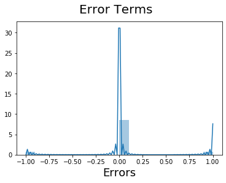

```python
# Plot the histogram of the error terms
fig = plt.figure()
sns.distplot((y_train - y_train_churn), bins = 20)
fig.suptitle('Error Terms', fontsize = 20)                  # Plot heading
plt.xlabel('Errors', fontsize = 18)                         # X-label
```

```python
# Dropping the constant from the dataframe
X_train_rfe = X_train_rfe.drop(['const'], axis=1)
```

We notice that if we remove more columns, the results don't improve.

### #9.2.5 Making Predictions - Test Data (LogReg + RFE + VIF)

```python
# Now let's use our model to make predictions.

# Creating X_test_new dataframe by dropping variables from X_test
X_test_new = X_test[X_train_rfe.columns]

# Adding a constant variable
X_test_new = sm.add_constant(X_test_new)
```

```python
# Adding constant
X_train_rfe = sm.add_constant(X_train_rfe)

#Viewing the shape of the
X_train_rfe.shape
```

```
(36352, 21)
```

```python
# Viewing the shape of the test data
X_test_new.shape
```

```
(8380, 21)
```

##### Score of Train DataL 84.99%

```python
# Viweing the score of the Test Data
round(logreg.score(X_train_rfe, y_train)*100,2)
```

```
84.99
```

##### Score of Test Data: 82.51 %

```python
# Viweing the score of the Test Data
round(logreg.score(X_test_new, y_test)*100,2)
```

```
82.51
```

The .score() function Returns the mean accuracy on the given test data and labels.

#### Trying out performance of Random Forest on Selected features with default parameters (Just to understand)

```python
from sklearn.ensemble import RandomForestClassifier
```

```python
random_forest = RandomForestClassifier(n_estimators=100)
random_forest.fit(X_train_rfe, y_train)

y_pred = random_forest.predict(X_test_new)
```

```python
round(random_forest.score(X_test_new, y_test),4)*100
```

```
76.58
```

### #9.2.6 Analysis of Results - Sensitivity and Type 2 Error - LogReg + RFE + VIF Analysis

```python
from sklearn.metrics import confusion_matrix

y_predicted = logreg.predict(X_test_new)
y_actual = y_test
print(confusion_matrix(y_actual, y_predicted))
```

```
[[6692 1104]
 [ 120  464]]
```

```python
# False Positive and False Negative
cm =confusion_matrix(y_actual, y_predicted)

TP = confusion_matrix(y_actual, y_predicted)[0][0]
FP = confusion_matrix(y_actual, y_predicted)[0][1]
FN = confusion_matrix(y_actual, y_predicted)[1][0]
TN = confusion_matrix(y_actual, y_predicted)[1][1]
total=sum(sum(cm))

print( " False Positive (Type I Error): ", FP)
print( " False Negative (Type II Error): ", FN)

# Accuracy
accuracy = round(100 - ((FP + FN)* 100 / len(y_predicted)),2)
print( "Accuracy: ", round(accuracy,2), '%')

# Sensitivity
sensitivity = round(TP*100 / (TP + FP),2)
print( "Sensitivity: ", sensitivity, '%')
```

```
 False Positive (Type I Error):  1104
 False Negative (Type II Error):  120
Accuracy:  85.39 %
Sensitivity:  85.84 %
```

Given that this is a classification analysis, the way to evaluate the method will be dependent on the business problem.

If we analyze the customer churn problem, the aim is to stop customers before they churn away from the service provider. Here, a way of looking the success criteria is two-fold as follows:

- **Minimize Type II Error:** This means that we should try to minimize missing out on cutomers who can leave and we did not identify. It is okay here to have a higher Type I error as we might end up targeting customers who are not in risk of shurn and this will not affect the telecom service provider as much
- **Maximize Sensitivity:** Sensitivity is an indicator of the True Positive Rate. Here, the aim is to get as many customers who might churn as possible, the higher this is, it is a better indicator of our problem

## #10 Model Output Discussion

The model that considered all the columns as is and was cleaned and processed to make the interpretable model performed fairly well in terms of expected scores.

For the Algorithm of **Logistic Regression + Recursive Feature Elimination**, we had fairly good results for a model that can run fast. So, this would be a **suggested method** to go ahead with.

However, the performance of the model Logistic Regression + RFE with PCA did not do that well on the test dataset.

From the above-analysis, the columns that are important to the business in terms of the data are as follows:

- og_others_8: Outgoing calls to others in the action-phase
- total_ic_mou_8: Total incoming calls as minutes of usage in the action phase
- loc_ic_mou_8: Local incoming calls from the same telecom operator in month 8
- std_ic_t2m_mou_8: STD incoming calls from another operator mobile minutes of usage in the action phase (month 8)
- isd_ic_mou_8: Incoming ISD calls minutes of usage in the action phase (month 8)
- night_pck_user_7: Night pack prepaid user in the good phase
- total_og_mou_7: Total outgoing calls for the month
- total_og_mou_8: Total minutes outgoing, minutes of usage for the action pahse (month 8)
- std_og_t2m_mou_8, std_og_t2t_mou_8, isd_ic_mou_8, loc_ic_mou_8: STD and ISD incoming and outgoing calls for a user
- loc_ic_t2m_mou_8, loc_og_t2m_mou_8, loc_og_mou_8, loc_ic_t2t_mou_8: Local calls from operator T to mobile in another operator
- sep_vbc_3g - KPI for month 9, volumne based cost for 3G data
- fb_user_8 - Service scheme to avail services of Facebook and similar social networking sites
- arpu_8 - Average revenue per user for the action month

Top 5 features:

## #11 Outputs of the Analysis

Here, we notice the following from the above analysis as the driving factors to identify customer churn:

The models that were run include the following:

## #12 Business Recommendations to reduce churn

The business requirements suggested that the asks of the business were to build a model to identify customers who are going to churn and identify the factor that affect churn.

Following are the business recommendations:

In terms of the model:

~Thank you for evaluating analysis.

This was an effort that took over 40 hours of work, I hope you had as much fun evaluating this as I had learning through the experience.~